# Kostenoffenlegung als Wettbewerbsvorteil

Chancen und Potenziale der Kostentransparenz

# Motivation

Die Untersuchung von Kostentransparenz ist aus ökonomischer Sicht besonders spannend, da sie Einblicke in das Zusammenspiel von Marktverhalten, Preiswahrnehmung und Konsumentenvertrauen ermöglicht. In klassischen Märkten gilt Information als asymmetrisch verteilt - insbesondere Kostenstrukturen bleiben für Konsument:innen meist verborgen. Wenn Unternehmen jedoch freiwillig ihre Produktionskosten offenlegen, entsteht eine neue Form der Marktkommunikation, die sowohl auf das Kaufverhalten als auch auf die Markenbindung Einfluss nehmen kann.

In diesem Projekt beschäftigen Sie sich mit der ökonomischen Wirkung unterschiedlicher Formen von Kostentransparenz, darunter produktbezogene Einzelkosten-Offenlegung im Point-of-Sale oder auch verbal vermittelte Transparenz in Kombination mit Vertrauensmessung. Ziel ist es, zu untersuchen, wie sich diese Varianten auf Zahlungsbereitschaft, Vertrauen und wahrgenommene Preisfairness auswirken.

Kern dieser Ausarbeitung ist die Frage, inwiefern Kostentransparenz eine rationale Kaufentscheidung unterstützt oder über emotionale Mechanismen - etwa durch erhöhte Markenattraktivität - wirkt. Für die Analyse greifen Sie auf ein breites Methodenrepertoire zurück, das ökonomische Modellierung mit experimenteller Verhaltensforschung verbindet, und leisten so einen Beitrag zum besseren Verständnis moderner Konsumentenentscheidungen in transparenten Märkten. Für ihre Analyse verwenden Sie die Daten der folgenden Ausarbeitung:

**Mohan, B., Buell, R. W., & John, L. K. (2020). Lifting the veil: The benefits of cost transparency. Marketing Science, 39(6), 1105-1121.**

# Aufbau der Studie

1. Lesen Sie sich den folgenden Text zum Hintergrund und Aufbau der Studie durch und beantworten Sie nachfolgende Fragen dazu:

Der Ausgangspunkt der betrachteten Untersuchung war ein reales Ereignis: Ein Online-Händler stellte im Dezember 2013 ein hochwertiges Lederportemonnaie zum Verkauf. Einige Wochen später wurde auf den Produktseiten eine Infografik zur Kostenzusammensetzung ergänzt, allerdings versehentlich nur bei drei von fünf Farbvarianten. Obwohl der Händler diesen Fehler nicht beabsichtigte, entstand daraus ein sogenanntes natürliches Experiment, also eine reale Vergleichssituation mit kontrollierbaren Unterschieden. Die Verkäufe konnten analysiert werden, um zu überprüfen, ob die Offenlegung der Produktionskosten einen Einfluss auf das Kaufverhalten hatte.

Dieses natürliche Experiment lieferte erste Hinweise darauf, dass Kostentransparenz wirkt - und war damit die Basis für zwei gezielte Experimente im Labor, die Sie sich in diesem Projekt genauer anschauen sollen. Beide Laborexperimente knüpfen an die reale Ausgangslage an - gehen aber unterschiedliche Forschungsfragen an:

Experiment 1: In einem realitätsnahen Online-Setting wurde untersucht, ob Konsument:innen anders entscheiden, wenn sie Informationen zu Produktionskosten sehen. Hierbei sahen die Teilnehmer:innen eine Produktseite für einen Rucksack von Everlane - entweder mit oder ohne Kostenaufstellung (vgl. Abbildung 1: Kostentransparenz Infografik im Anhang). Zusätzlich wurde ein Vergleichsprodukt von J. Crew gezeigt (ohne Hinweise zur Kostenzusammensetzung). Die Teilnehmer:innen mussten entscheiden, von welchem Anbieter sie lieber einen Gutschein erhalten würden. Das Ziel der Forscher war es zu messen, ob Konsument:innen bei mehr Transparenz auch eher kaufen, folglich sich für diesen Gutschein entscheiden.

Experiment 2: Nachdem Experiment 1 zeigte, dass es einen Effekt der Kostentransparenz gibt, stellt sich die psychologische Anschlussfrage, warum es diesen Effekt gibt und wie dieser festzumachen ist. So sahen die Teilnehmer:innen im 2. Experiment ein fiktives Produkt - eine Schokoladentafel. In der Kontrollgruppe wurden nur übliche Produktinfos gezeigt. In der Treatmentgruppe gab es zusätzlich eine detaillierte Kostenaufstellung (vgl. Abbildung 2: Design der Schokoladenverpackung ohne und mit Kostentransparenz im Anhang). Im Anschluss wurden Vertrauen in die Marke und Kaufbereitschaft durch einen Fragebogen abgefragt. So sollte herausgefunden werden, ob Vertrauen der zentrale psychologische Mechanismus für die Kaufentscheidung der Kund:innen ist.

Beantworten Sie nun folgende Fragen:

1. Welches reale Ereignis war der Auslöser der Forschung?
2. Welche konkrete Verhaltensfrage steht im Mittelpunkt von Experiment 1 - Was wollten die Forscher:innen direkt am Kaufverhalten testen?
3. Welcher psychologische Faktor steht im Zentrum von Experiment 2 - und wie hängt er mit dem Kaufverhalten zusammen?

*a):*

Ein Online-Händler veröffentlichte im Dezember 2013 versehentlich eine Infografik zur Produktionskostenzusammensetzung bei nur drei von fünf Farbvarianten eines Lederportemonnaies.

*b):*

Die Forscher:innen wollten testen, ob Konsument:innen sich eher für ein Produkt entscheiden, hier: einen Gutschein für einen Händler, wenn ihnen Kostentransparenz (Produktionskosten) offengelegt wird.

*c):*

Im Mittelpunkt steht das Vertrauen in das Unternehmen. Kostentransparenz wird als eine Form von offener Kommunikation verstanden, die Vertrauen fördert. Dieses gesteigerte Vertrauen erhöht wiederum die Kaufbereitschaft der Konsument:innen.

Nachdem Sie nun die grundlegende Forschungsidee und Zielsetzung der beiden Experimente kennengelernt haben, befassen wir uns im nächsten Schritt vertiefend mit Experiment 1. Ziel ist es, den genauen Aufbau, sowie das konkrete Verhalten der Teilnehmer:innen besser zu verstehen.

2. Lesen Sie sich den folgenden Text zum Aufbau des ersten Experiments durch und beantworten Sie anschließend Fragen dazu:

Cost transparency refers to the disclosure of the costs to produce a good or provide a service. Although cost transparency is a strategy traditionally employed in the context of supplier-firm relationships, wherein the two-way sharing of cost information between parties facilitates collaboration on cost reduction measures, we investigate its effects within the context of consumer-firm relationships. Information on the costs associated with providing goods and services is rarely shared with consumers, but we provide evidence of when and why voluntarily doing so can increase consumers’ purchase interest. Specifically, building on the psychology of disclosure and trust, we posit that cost transparency, insofar as it represents an act of intimate disclosure, fosters trust. In turn, we propose that this heightened trust increases consumers’ willingness to purchase from the transparent firm. In the sections that follow, we discuss our central predictions and highlight alternative accounts. Then, we present experiments, conducted in the lab and in the field, that document the main effects of cost transparency, its underlying psychological drivers, and conditions that moderate its effects.

This first experiment explores how cost transparency influences consumer preferences in an online shopping context. The study was designed as a between-subjects randomized experiment using an incentive-compatible setup, meaning participants made real choices with the possibility of receiving a tangible reward. A total of 509 U.S.-based participants were recruited through Amazon Mechanical Turk (MTurk). Each participant was randomly assigned to one of two experimental conditions:

- Cost Transparency Condition: Participants were shown a simulated product page for a backpack sold by the retailer Everlane. This page included a cost breakdown infographic, listing the production costs such as materials, labor, transport, and duties, with a clearly stated total cost.
- Control Condition: Participants saw the same backpack from Everlane but without any cost information. In both conditions, participants also saw a comparable backpack from J. Crew, which does not practice cost transparency.

Participants were instructed to view both product pages and then asked which company they would prefer to receive a $50 gift card from. Their response served as the main behavioral outcome, representing a choice between the transparent vs. non-transparent retailer. To ensure accurate interpretation of the presented information, a comprehension check followed the main choice question. Participants were also asked for demographic information such as age, gender, income, and education, to allow for potential control variables in later analysis.

*Antwort:*

1. Wie viele Personen nahmen final an dem Experiment teil?
2. Worin bestand der Unterschied zwischen der Transparenzbedingung und der Kontrollbedingung?
3. Welche Anreizstruktur wurde verwendet, um die Entscheidung der Teilnehmenden realistisch zu gestalten?
4. Wie unterschieden sich die beiden gezeigten Onlinehändler im Experiment?
5. Warum wurde im Anschluss an die Entscheidungsfrage ein Verständnischeck durchgeführt?
6. In der Beschreibung des Experiments wird von “between-subjects randomized experiment using an incentive-compatible setup” gesprochen. Was versteht man hierunter im Detail?

*Hinweis:* Für die Beantwortung der letzten Frage können Sie [diesen Artikel (Seite 1-5)](https://www.researchgate.net/publication/268269783_Incentives_in_Experiments_A_Theoretical_Analysis) als Grundlage verwenden.

*Antwort:*

*a)* Es nahmen insgesamt 509 Personen am Experiment teil.

*b)* In der Transparenzbedingung sahen die Teilnehmer eine Produktseite mit einer detaillierten Kostenaufstellung (Infografik)für den Rucksack. In der Kontrollbedingung wurde dieselbe Seite gezeigt, aber ohne Kostendetails.

*c)*Es wurde ein incentive-kompatibles Setup genutzt: Die Teilnehmer:innen konnten tatsächlich einen $50-Gutschein gewinnen.

*d)*Beide Gruppen sahen immer auch das J.Crew-Produkt, aber nur Everlane variierte zwischen Transparenz und Nicht-Transparenz. Dadurch diente J.Crew als konstanter Vergleichspartner, und nur Everlane war „manipuliert“.

*e)*Der Verständnischeck sollte sicherstellen, dass die Teilnehmer:innen die angezeigten Informationen korrekt verstanden haben – um valide Aussagen über deren Entscheidungen treffen zu können.

*f)*Bei einem between-subjects randomized experiment handelt es sich um ein Versuchsdesign, bei dem die Teilnehmenden zufällig nur einer einzigen Versuchsbedingung zugewiesen werden. Das bedeutet, dass jede Person entweder die Version mit Kostentransparenz oder die Kontrollversion ohne Transparenz sieht, jedoch nicht beide. Durch diese zufällige Zuteilung soll sichergestellt werden, dass sich die Gruppen im Durchschnitt nur durch die experimentelle Manipulation unterscheiden und keine systematischen Verzerrungen entstehen. Ein incentive-kompatibles Setup bedeutet, dass die Entscheidung, die die Teilnehmenden im Experiment treffen, reale Konsequenzen haben kann. Im konkreten Fall heißt das, dass die Befragten tatsächlich die Chance auf einen 50-Dollar-Gutschein hatten, je nachdem, welchen Anbieter sie bevorzugten. Diese Anreizstruktur führt dazu, dass sich die Teilnehmenden so verhalten, wie sie es auch in einer echten Kaufsituation tun würden, was die Gültigkeit der Ergebnisse erhöht.

# Daten

## Datenimport und -aufbereitung

Die Daten, die Sie für die nachfolgenden Analysen verwenden, wurden zu Replikationszwecken von den Autoren der Studie zur Verfügung gestellt und können hier heruntergeladen werden:

**Bhavya Mohan, Ryan W. Buell, Leslie K. John (2020) Lifting the Veil: The Benefits of Cost Transparency. Marketing Science 39(6):1105-1121. mksc.2019.1200.sm1.pdf**

Wir haben die Daten für Sie heruntergeladen und im Unterordner mit dem Namen `Daten` bereitgestellt. Für ihre Analyse werden die Dateien `Experiment1.csv` und `Experiment2.csv` genutzt. Für die Zusatzaufgabe ist die Datei `Experiment3.csv` relevant.

3. Lesen Sie den Datensatz `Experiment1.csv` aus dem Unterordner `Daten` in R ein. Nennen Sie den Datensatz in R `daten_exp1`.

Im Datensatz sind unterschiedliche Variablen enthalten. Weiterhin habe wir Ihnen ein Readme mit den Beschreibungen zu den Variablen bereitgestellt. Nutzen Sie dieses und den Text aus Aufgabe 2, um die Variablen zu beschreiben.

Hier bitte ihren **Code und** ihre **Antwort** eintragen

*Antwort:*

Der Datensatz daten_exp1 enthält Informationen aus einem Experiment, das untersucht, wie sich Kostentransparenz auf Konsumentscheidungen auswirkt. Die Proband:innen wurden zufällig einer von zwei Bedingungen zugeordnet – mit oder ohne Informationen zu den Produktionskosten eines Produkts. Die zentrale abhängige Variable ist die Wahl einer Geschenkkarte, die eine Präferenz für den jeweiligen Händler widerspiegelt.

*Variablenbeschreibung:*

*treatment:* Gibt an, ob ein:e Teilnehmer:in in der Kostentransparenz-Bedingung war (1 = Transparenz gezeigt, 0 = Kontrollgruppe).

*everlane:* Binäre Variable für die Wahl der Geschenkkarte – 1 = Everlane (transparentes Unternehmen), 0 = J. Crew (kein Kostenhinweis).

*passed:* Zeigt an, ob der Verständnis-Test bestanden wurde (1 = bestanden, 0 = nicht bestanden). Diese Frage diente der Qualitätssicherung der Daten.

*email_provided:* Gibt an, ob Teilnehmer:innen eine E-Mail-Adresse hinterlassen haben, um die Geschenkkarte zu erhalten (1 = ja, 0 = nein).

*age:* Alter der Teilnehmenden (freie Eingabe, numerisch).

*educ:* Bildungsniveau (1 = Einige Jahre Schule, 2 = Schulabschluss, 3 = Einige Jahre College, 4 = Hochschulabschluss, 5 = Postgraduale/berufliche Ausbildung).

*income:* Monatliches Einkommen in 12 Kategorien: 1 = “kein Einkommen”; 2 = Unter 60 Dollar; 3 = 60-499 Dollar; 4 = 500-999 Dollar; 5 = 1.000-1.999 Dollar; 6 = 2.000-2.999 Dollar; 7 = 3.000-3.999 Dollar; 8 = 4.000-4.999 Dollar; 9 = 5.000-7.499 Dollar; 10 = 7.500-9.999 Dollar; 11 = Über 10.000 Dollar; 12 = “Weiß nicht/Bevorzuge keine Antwort”;

## Deskriptive Analyse

Sie sollten sich im ersten Schritt einen Überblick über ihre Daten verschaffen.

4. Auf Basis des Datensatzes `daten_exp1` aus Aufgabe 3 erstellen Sie eine deskriptive Tabelle mit der Anzahl an Beobachtungen, den Mittelwerten, der Standardabweichungen, dem Median, sowie den Minima und Maxima für alle in `daten_exp1` enthaltenen Variablen.

Beschreiben und interpretieren Sie ihre Tabelle. Gehen Sie insbesondere auf die Verteilungen der einzelnen Variablen ein. Was fällt hier besonders auf.

Deskriptive Statistik für den Datensatz `daten_exp1`

| Variable | Beobachtungen | Mittelwert | Standardabweichung | Median | Minimum | Maximum |
| --- | --- | --- | --- | --- | --- | --- |
| treatment | 509 | 0.50 | 0.50 | 0 | 0 | 1 |
| everlane | 509 | 0.63 | 0.48 | 1 | 0 | 1 |
| passed | 509 | 0.77 | 0.42 | 1 | 0 | 1 |
| email_provided | 509 | 0.56 | 0.50 | 1 | 0 | 1 |
| female | 509 | 0.49 | 0.50 | 0 | 0 | 1 |
| age | 505 | 37.59 | 11.74 | 35 | 18 | 81 |
| educ | 505 | 3.76 | 0.84 | 4 | 1 | 5 |
| income | 488 | 4736.82 | 3236.17 | 4500 | 0 | 11000 |
| income_class | 505 | 7.58 | 2.43 | 8 | 1 | 12 |

*Antwort:*

Die Variable *treatment* hat bei 509 Beobachtungen einen Mittelwert von 0,50, eine Standardabweichung von 0,50, einen Median von 0 sowie einen Minimalwert von 0 und einen Maximalwert von 1. Da es sich hierbei um eine binäre Variable handelt (0 = Kontrollgruppe, 1 = Transparenzgruppe), deutet der Mittelwert von exakt 0,5 darauf hin, dass die Teilnehmer:innen gleichmäßig auf die beiden Gruppen verteilt wurden. Dies bestätigt die erfolgreiche Randomisierung im Experiment.

Die Variable *everlane*, die angibt, ob sich die Teilnehmer:innen für die Everlane-Geschenkkarte entschieden haben, weist bei 509 Beobachtungen einen Mittelwert von 0,63, eine Standardabweichung von 0,48, einen Median von 1 sowie einen Minimalwert von 0 und einen Maximalwert von 1 auf. Das bedeutet, dass sich 63 % der Teilnehmer:innen für das Unternehmen mit Kosten-Transparenz entschieden haben. Diese Präferenz spricht dafür, dass Transparenz im Onlinehandel positiv auf das Konsumentenverhalten wirken könnte. Die Verteilung ist leicht linksschief, da mehr Personen Everlane (1) gewählt haben als J.Crew (0).

Die Variable *passed* zeigt bei ebenfalls 509 Beobachtungen einen Mittelwert von 0,77, eine Standardabweichung von 0,42, einen Median von 1 sowie einen Minimalwert von 0 und einen Maximalwert von 1. Daraus lässt sich schließen, dass 77 % der Teilnehmer:innen den Verständnis-Test bestanden haben, was für eine hohe Aufmerksamkeit und ein gutes Verständnis der experimentellen Inhalte spricht. Auch hier ist die Verteilung linksschief, da ein Großteil den Test erfolgreich absolvierte.

Die Variable *email_provided* weist bei 509 Beobachtungen einen Mittelwert von 0,56, eine Standardabweichung von 0,50, einen Median von 1 sowie einen Minimalwert von 0 und einen Maximalwert von 1 auf. Das bedeutet, dass etwa 56 % der Teilnehmer:innen bereit waren, ihre E-Mail-Adresse für den Erhalt der Geschenkkarte anzugeben. Diese freiwillige Angabe kann als Ausdruck eines gewissen Vertrauens oder einer ernsthaften Teilnahme gewertet werden.

Die Variable *female*, bei der das Geschlecht abgefragt wurde, hat bei 509 Beobachtungen einen Mittelwert von 0,49, eine Standardabweichung von 0,50, einen Median von 0 sowie einen Minimalwert von 0 und einen Maximalwert von 1. Dies deutet auf eine nahezu gleichmäßige Geschlechterverteilung hin, wobei etwa 49 % der Teilnehmer:innen weiblich waren. Die Verteilung ist daher annähernd symmetrisch.

Die Variable *age* umfasst 505 gültige Beobachtungen (also mit 4 fehlenden Werten) und zeigt einen Mittelwert von 37,59 Jahren, eine Standardabweichung von 11,74 Jahren, einen Median von 35 Jahren, ein Minimum von 18 Jahren und ein Maximum von 81 Jahren. Die leicht höhere Differenz zwischen Mittelwert und Median spricht für eine geringfügig rechtsschiefe Verteilung. Einige ältere Teilnehmer:innen heben den Mittelwert über den Median. Insgesamt handelt es sich um eine vergleichsweise erwachsene Stichprobe für eine Plattform wie MTurk.

Die Variable *educ*, die das Bildungsniveau erfasst, hat ebenfalls 505 gültige Beobachtungen. Der Mittelwert liegt bei 3,76, die Standardabweichung bei 0,84, der Median bei 4, der Minimalwert bei 1 und der Maximalwert bei 5. Da der Median dem Wert 4 entspricht (Hochschulabschluss) und der Mittelwert knapp darunter liegt, zeigt sich, dass die Mehrheit der Teilnehmer:innen eine höhere Bildung aufweist. Die Verteilung ist leicht linksschief, da viele höhere Werte auftreten.

Die Variable *income* basiert auf den Klassenmittelwerten der gemeldeten monatlichen Einkommen und liegt für 488 gültige Beobachtungen vor. Der Mittelwert beträgt 4.736,82 USD, mit einer Standardabweichung von 3.236,17 USD. Der Median liegt bei 4.500 USD, was der Einkommenskategorie „4.000–4.999 USD“ entspricht. Das Minimum liegt bei 0 USD („kein Einkommen“), das Maximum bei 11.000 USD (für die Kategorie „über 10.000 USD“).

Die ursprüngliche kategoriale Variable *income* wurde so angepasst, dass jeder Einkommensklasse ihr jeweiliger Klassenmittelwert zugewiesen wurde. Die letzte Einkommenskategorie („über 10.000 USD“) wurde mit 11.000 USD angesetzt, während die Sonderkategorie 12 („weiß nicht/keine Angabe“) als fehlend (NA) behandelt wurde. Da die Klassen unterschiedlich breit sind und einzelne Kategorien entweder keine oder sehr niedrige Einkommen (z. B. 0 USD) umfassen, verbessert diese Transformation die Aussagekraft von Mittelwert, Standardabweichung und insbesondere den Ergebnissen späterer Regressionsanalysen deutlich.

Die Variable *income_class* entspricht der ursprünglichen Variable *income* und hat 505 gültige Beobachtungen. Der Mittelwert liegt bei 7,58, die Standardabweichung bei 2,43, der Median bei 8, das Minimum bei 1 und das Maximum bei 12. Der Medianwert entspricht der Einkommenskategorie „4.000–4.999 USD“, was relativ hoch ist. Da der Maximalwert (12) für „weiß nicht/keine Angabe“ steht und keine echte Einkommenshöhe darstellt, kann dies die Verteilung verzerren. Die Daten deuten insgesamt auf eine eher einkommensstarke Stichprobe hin, wobei die Verteilung durch die Sonderkategorie 12 etwas an Genauigkeit verliert.

5. Im Datensatz `daten_exp1` gibt es Variablen für die keine Beobachtungen vorhanden sind.
- Gegeben ihrer Variablenbeschreibung in Aufgabe 3:
  - Macht es Sinn die Beobachtungen aus dem Datensatz zu entfernen, wenn für bestimmte Variablen keine Werte vorhanden sind?
  - Wenn ja, warum?
  - Wie viele Beobachtungen entfernen Sie dadurch aus ihrem Datensatz?

Entfernen Sie nun alle Beobachtungen (d.h. gesamte Zeilen aus dem Datensatz), bei denen für mindestens eine der erhobenen Variablen kein Wert vorliegt, da unvollständige Daten für die Analyse nicht berücksichtigt werden sollen.

Untersuchen Sie weiterhin, ob sich die Teilnehmer, die die Webseite mit der Kostentransparenz gesehen haben (Treatmentgruppe), systematisch von jenen unterscheiden, die die Kontrollversion gesehen haben. Auch wenn es sich um ein Experiment handelt, bei dem die Zuteilung zu den Gruppen zufällig erfolgt ist, sollten Sie dennoch prüfen, ob es unbeabsichtigte (systematische) Unterschiede zwischen den Gruppen gibt. Erstellen Sie hierfür eine Balancing-Tabelle, in der Sie die Mittelwerte von Alter (age), Geschlecht (female), Einkommensstufe (income) und Bildungsniveau (educ) zwischen den beiden Gruppen vergleichen, die Differenzen berechnen und mithilfe von T-Tests prüfen, ob diese Unterschiede statistisch signifikant sind.

- Beschreiben und interpretieren Sie ihre Tabelle.
  - Was fällt Ihnen in Bezug auf die p-Werte auf?
  - Was müssten Sie bei einer weiteren Regressionsanalyse berücksichtigen?

*Hinweis:* Die beiden Gruppen, die Sie in der Balancing Tabelle betrachten sollen, können aus den Werten (1 und 0) der Variable `treatment` abgeleitet werden.

Balancing-Tabelle: Vergleich zwischen Kontrollgruppe (242) und Treatmentgruppe (246)

| Variable | Mittelwert (Kontrolle) | Mittelwert (Treatment) | Differenz | t-Wert | p-Wert |
| --- | --- | --- | --- | --- | --- |
| age | 37.96 | 37.44 | 0.52 | 0.49 | 0.63 |
| female | 0.48 | 0.49 | 0.01 | -0.18 | 0.86 |
| income | 4572.36 | 4904.01 | 331.65 | -1.13 | 0.26 |
| educ | 3.74 | 3.80 | 0.07 | -0.86 | 0.39 |

*Antwort:*

*Macht es Sinn, Beobachtungen mit fehlenden Werten zu entfernen?*

Ja, unter bestimmten Bedingungen macht das Entfernen fehlender Werte Sinn:

*Wenn ja, warum?*

Die Variablen mit fehlenden Werten (age, educ, income) sind demografische Kontrollvariablen, die häufig in Regressionsanalysen verwendet werden. Wenn man eine Analyse plant, bei der diese Variablen als Kovariaten verwendet werden (z. B. Regressionsmodelle oder Gruppenvergleiche mit Kontrolle für Alter, Bildung und Einkommen), dann ist es notwendig, dass für alle Beobachtungen Werte in diesen Variablen vorliegen. Werden Beobachtungen mit fehlenden Werten nicht entfernt, müssen diese entweder durch Imputation ersetzt oder in Modellen ausgeschlossen werden, was zu inkonsistenter Stichprobengröße und verzerrten Ergebnissen führen kann. Wenn die fehlenden Werte zufällig (MCAR) sind, hat das Entfernen keine systematische Verzerrung zur Folge.

*Wie viele Beobachtungen würden entfernt werden?*

509 – 488 = 21 Beobachtungen enthalten fehlende Werte in mindestens einer dieser drei Variablen. Hier sind auch die Beobachtungen inkludiert bei denen *income_claSS*= 12. Wenn man alle Fälle entfernt, in denen einer dieser drei Werte fehlt, reduziert sich der Datensatz auf 488 Beobachtungen.

*Beschreibung und Interpretation:*

Die Balancing-Tabelle zeigt, dass sich die Kontroll- und Treatmentgruppe hinsichtlich der untersuchten demografischen Variablen insgesamt sehr ähnlich sind. Beim *Alter (age)* beträgt der durchschnittliche Unterschied zwischen den Gruppen lediglich 0.52 Jahre. Dieser Unterschied ist statistisch nicht signifikant (p = 0.63), was auf eine ausgeglichene Altersverteilung zwischen den Gruppen hinweist. Auch in Bezug auf das *Geschlecht (female)* bestehen keine Unterschiede: Der Anteil weiblicher Teilnehmer:innen liegt in beiden Gruppen nahezu gleich bei 0.48 (Kontrollgruppe) bzw. 0.49 (Treatmentgruppe). Der p-Wert von 0.86 belegt, dass es hier keinerlei statistisch relevanten Unterschied gibt – die Verteilung ist also nahezu perfekt balanciert.

Etwas auffälliger ist die Differenz beim *Einkommen (income)*. Die Treatmentgruppe weist mit einem Durchschnitt von 4904 gegenüber 4572 in der Kontrollgruppe einen leicht höheren Mittelwert auf. Die Differenz von 331 ist jedoch nicht statistisch signifikant (p = 0.26), bewegt sich aber in einem Bereich, der auf eine gewisse Unausgewogenheit hindeuten könnte. Beim *Bildungsniveau (educ)* zeigt sich ein kleiner Unterschied von 0.07 Punkten zugunsten der Treatmentgruppe (3.74 vs. 3.80), der mit einem p-Wert von 0.39 ebenfalls nicht signifikant ist.

*Zusammenfassend* lässt sich sagen, dass die Randomisierung im Experiment grundsätzlich funktioniert hat, da keine der betrachteten Variablen signifikant unterschiedlich verteilt ist. Dennoch könnte der vergleichsweise niedrige p-Wert bei der Einkommensvariable darauf hinweisen, dass es sinnvoll wäre, in späteren Analysen demografische Kontrollvariablen wie income, age, female und educ mit aufzunehmen, um potenzielle Verzerrungen auszuschließen.

*Was fällt bei den p-Werten auf?:*

Keiner der Unterschiede ist statistisch signifikant, alle p-Werte liegen deutlich über dem klassischen Signifikanzniveau von 0.05. Somit kann die Nullhypothese eines Unterschieds zwischen den Gruppen in keiner der untersuchten demografischen Variablen verworfen werden. Die Unterschiede sind also mit hoher Wahrscheinlichkeit zufallsbedingt, was die Qualität der Randomisierung im Experiment zusätzlich bestätigt.

*Implikationen für weitere Regressionsanalysen:*

Auch wenn die Gruppen zufällig zugewiesen wurden, empfiehlt es sich aus Vorsichtsgründen, bei späteren Regressionsanalysen Kontrollvariablen wie income, age, female und educ mit aufzunehmen, um mögliche kleine Ungleichgewichte statistisch abzusichern. Dies erhöht die Effizienz der Schätzung und stellt sicher, dass etwaige Effekte der Treatmentbedingung nicht auf demografische Unterschiede zurückzuführen sind.

Nachdem Sie sich in den vorangegangenen Aufgaben bereits mit der Verteilung der Daten und den Unterschieden zwischen den einzelnen Gruppen auseinandergesetzt haben, geht es nun um eine explorative Betrachtung von Zusammenhängen zwischen den zentralen Variablen im Datensatz.

6. In dieser Aufgabe führen Sie eine Korrelationsanalyse durch, um herauszufinden, ob und wie stark einzelne Merkmale - wie Alter, Bildung, Einkommen oder Geschlecht - mit der Treatment-Zugehörigkeit sowie der Entscheidung für die Everlane-Gutscheinkarte zusammenhängen.

Wählen Sie die folgenden Variablen aus dem Datensatz `daten_exp1` aus:

- treatment
- everlane
- age
- income
- educ
- female

Berechnen Sie die Korrelationsmatrix dieser Variablen. Visualisieren Sie die Matrix (als Tabelle oder Grafik), in der die Korrelationskoeffizienten und deren Stärke farblich dargestellt sind.

Beschreiben und interpretieren Sie ihre Tabelle/Grafik. Gehen Sie hierbei auch auf folgende Fragen ein:

- Was bedeutet ein positiver Zusammenhang (Korrelation) zwischen `treatment` und `everlane` im Kontext der Hypothese, dass Kostentransparenz die Entscheidung für Everlane beeinflusst?
- Warum kann eine Korrelation auf einen Zusammenhang hinweisen, aber nicht ausreichen, um einen kausalen Effekt nachzuweisen - selbst wenn wir wissen, dass `treatment` im Experiment zufällig zugewiesen wurde?
- Was nützt ihnen eine Korrelationsmatrix im Vergleich zu einem einfachen Mittelwertvergleich zwischen den Gruppen?

*Hinweis:* Für die Darstellung der Korrelationsmatrix können Sie z.B. das Paket corrplot verwenden.

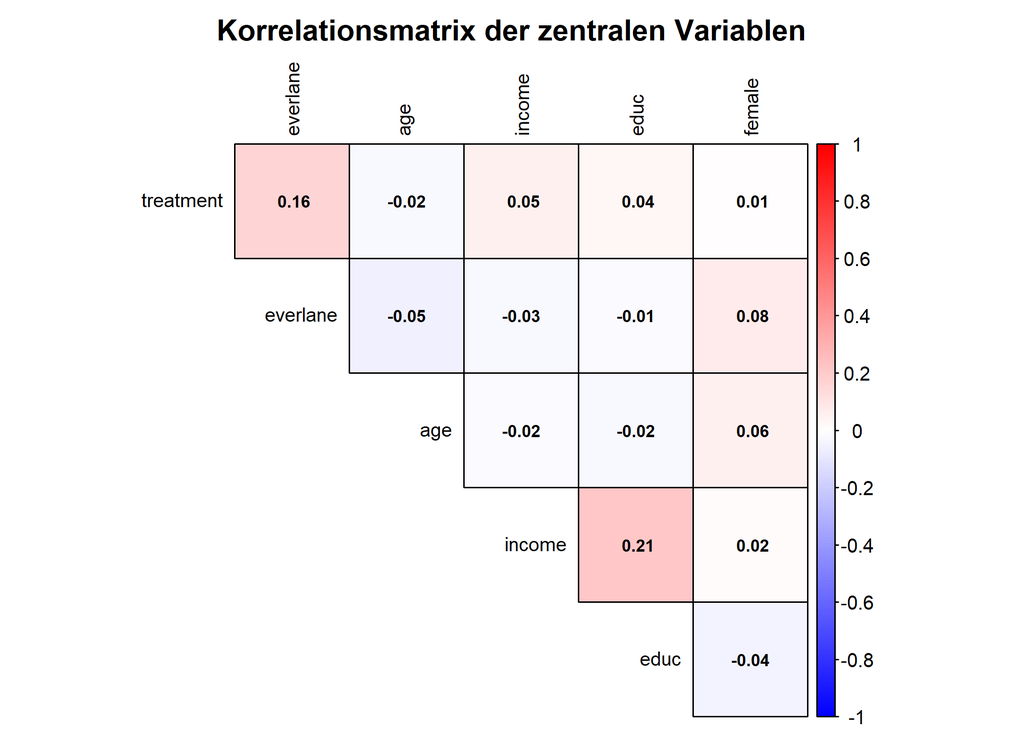

*Antwort:*

*Beschreibung und Interpretation:*

Die Korrelationsmatrix zeigt die linearen Zusammenhänge zwischen den sechs zentralen Variablen des Datensatzes: *treatment*, *everlane*, *age*, *income*, *educ* und *female*. Farblich wird die Stärke der Korrelation visualisiert – dunklere Rottöne stehen für stärkere positive Korrelationen, Blautöne für negative Zusammenhänge. Die meisten Korrelationen liegen im schwachen bis sehr schwachen Bereich.

Ein besonders interessanter positiver Zusammenhang zeigt sich zwischen *treatment* und der Wahl der *everlane*-Geschenkkarte (r = 0.16). Dieser Wert deutet darauf hin, dass Teilnehmer:innen der Treatmentgruppe – also der Gruppe, die Preistransparenz erhielt – tendenziell eher Everlane wählten. Obwohl der Zusammenhang nicht stark ist, stützt er die Annahme, dass Kostentransparenz Einfluss auf Konsumentscheidungen haben kann.

Eine weitere moderate positive Korrelation besteht zwischen *income* und *educ* (r = 0.21). Das entspricht der erwartbaren Beobachtung, dass höher gebildete Personen im Durchschnitt ein höheres Einkommen erzielen – ein klassisches Muster in sozioökonomischen Daten.

Im Gegensatz dazu zeigen viele andere Variablen kaum systematische Zusammenhänge. So liegen etwa die Korrelationen von *age* mit anderen Variablen (z. B. *treatment*: -0.02, *income*: -0.02) und die von *female* (z. B. mit *educ*: -0.04, mit *treatment*: 0.01) nahe bei null. Diese Werte deuten darauf hin, dass weder Alter noch Geschlecht in bedeutsamer Weise mit Treatment-Zuweisung oder den übrigen Merkmalen assoziiert sind.

Insgesamt zeigt die Matrix, dass der Datensatz weitgehend frei von starken linearen Zusammenhängen zwischen den zentralen Kovariaten ist – ein gutes Zeichen für die interne Validität des Experiments. Insbesondere die moderate Korrelation zwischen Treatment und der Wahl für Everlane liefert einen ersten Hinweis auf einen potenziellen Effekt der Kostentransparenzintervention.

*Was bedeutet die positive Korrelation zwischen treatment und everlane?:*

Ein positiver Korrelationskoeffizient von 0.16 zwischen treatment (Zugehörigkeit zur Transparenz-Gruppe) und everlane (Wahl von Everlane) bedeutet: Je eher jemand in der Treatment-Gruppe war, desto eher wählte er/sie die Everlane-Geschenkkarte. Das unterstützt die Hypothese, dass Transparenz zu einem anderen Entscheidungsverhalten führt, hier zugunsten des transparenten Unternehmens.

*Warum reicht Korrelation nicht für Kausalität?:*

Auch wenn treatment zufällig zugewiesen wurde, ist eine Korrelation allein kein Beweis für Kausalität, denn:

-Korrelation misst nur Zusammenhang, nicht Ursache.

-Es könnte verdeckte Störvariablen geben, die beide Variablen beeinflussen (z. B. persönliches Interesse an nachhaltigen Marken).

-Es wird keine zeitliche Reihenfolge berücksichtigt.

Selbst in einem Experiment kann die Korrelation durch Zufallsschwankungen oder selektive Ausfälle verzerrt sein. Ein kausaler Effekt wird besser durch eine Regression oder Mittelwertvergleich mit Signifikanztest innerhalb eines sauberen experimentellen Designs erfasst.

*Wozu ist eine Korrelationsmatrix nützlich – im Vergleich zum Mittelwertvergleich?.*

Eine Korrelationsmatrix zeigt alle linearen Beziehungen zwischen mehreren Variablen gleichzeitig, auch zwischen den Kovariablen (z. B. income und educ). Sie hilft, Multikollinearität in Regressionsmodellen zu erkennen. Sie ist außerdem besonders nützlich in der explorativen Phase, um Hinweise auf mögliche Zusammenhänge zu finden. Ein Mittelwertvergleich hingegen ist gezielter und einfacher, aber nur für den Vergleich von zwei Gruppen in Bezug auf eine Variable geeignet, z. B. wie sich everlane-Wahl zwischen Treatment und Kontrolle unterscheidet.

7. In Aufgabe 1 und 2 haben Sie gelesen, dass den Teilnehmern ein Angebot gemacht wurde, eine Everlane-Gutscheinkarte anzunehmen. Erzeugen Sie eine geeignete Grafik, die den durchschnittlichen Anteil der angenommenen Angebote (d.h. den Anteil, in dem die Everlane-Karte gewählt wurde) getrennt für die Treatment- und die Kontrollgruppe darstellt. Fügen Sie in der Grafik zusätzlich den Standardfehler der Mittelwerte ein. Führen Sie einen T-Test durch, um zu prüfen, ob der Unterschied im Mittelwert zwischen der Treatment- und Kontrollgruppe statistisch signifikant ist, und geben Sie das Testergebnis (den p-Wert) deutlich sichtbar in der Grafik an. Achten Sie dabei auf eine verständliche Beschriftung Ihrer Grafik sowie auf einen aussagekräftigen Titel.

Beschreiben und interpretieren Sie ihre Grafik. Gehen Sie insbesondere auf folgende Fragen ein:

- Welche Aussage lässt sich auf Basis des durchgeführten T-Tests treffen?
- Welche der in den vorherigen Aufgaben (vgl. Aufgabe 4 und 5) analysierten Faktoren könnten dazu beigetragen haben, dass ein signifikanter Unterschied im Anteil angenommener Everlane-Angebote zwischen Treatment- und Kontrollgruppe beobachtet wird?

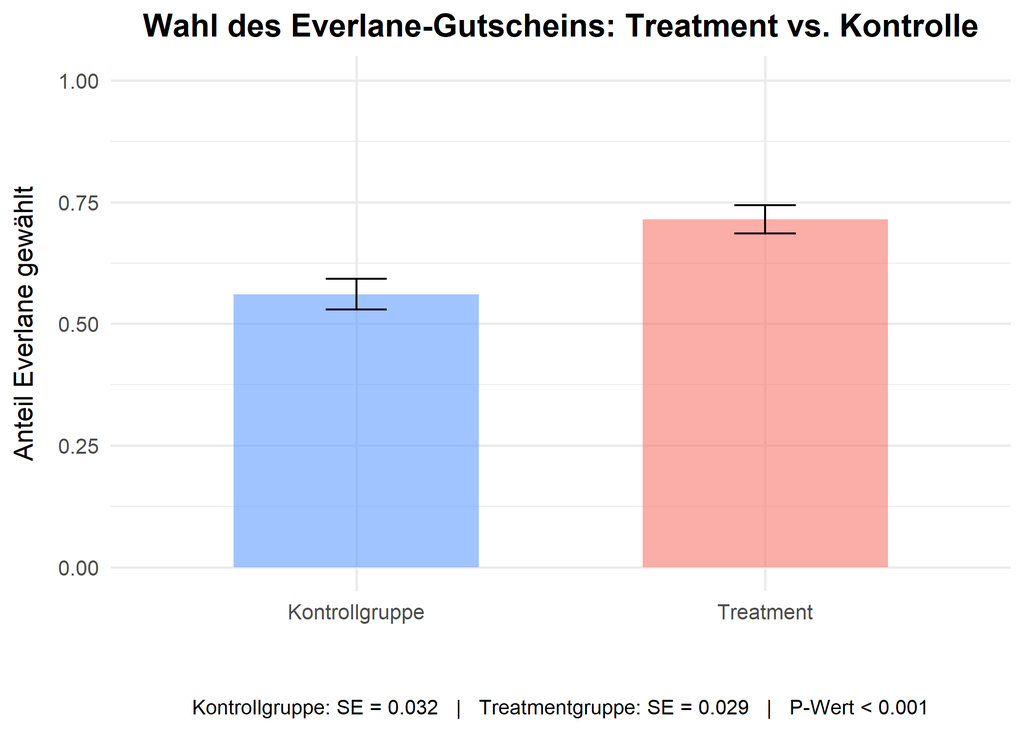

*Antwort:*

*Beschreibung:*

Die dargestellte Balkengrafik mit dem Titel „Wahl des Everlane-Gutscheins: Treatment vs. Kontrolle“ zeigt den durchschnittlichen Anteil der Teilnehmer:innen, die sich im Rahmen des Experiments für einen Everlane-Gutschein entschieden haben. Die Werte sind getrennt für die Kontrollgruppe und die Treatmentgruppe dargestellt. Die y-Achse zeigt den Anteil der Teilnehmer:innen, die Everlane gewählt haben, während die x-Achse die Gruppenzugehörigkeit angibt. Die Balken stellen jeweils den Mittelwert dar, und die daran angeschlossenen Linien visualisieren den Standardfehler des Mittelwerts, was eine Einschätzung über die statistische Streuung erlaubt. Die Kontrollgruppe zeigt einen durchschnittlichen Anteil von ca. 55 %, die Treatmentgruppe hingegen einen Anteil von etwa 70 %. Dies bedeutet, dass die Teilnehmer:innen in der Treatmentgruppe signifikant häufiger die Everlane-Karte gewählt haben als in der Kontrollgruppe. Unterhalb der Balken ist der P-Wert vermerkt (p < 0.001), was auf die Signifikanz des Unterschieds zwischen den beiden Gruppen hinweist.

*Interpretation:*

*Ergebnis des t-Tests:*

Der in der Grafik angegebene p-Wert von < 0.001 belegt, dass der Unterschied in der Wahl der Everlane-Karte zwischen Kontroll- und Treatmentgruppe hochsignifikant ist. Das bedeutet: Die Wahrscheinlichkeit, dass dieser Unterschied zufällig entstanden ist, beträgt weniger als 0.1 %. Wir können daher mit hoher statistischer Sicherheit schließen, dass die Transparenz einen kausalen Einfluss auf die Wahlentscheidung hatte. Die Intervention, also das, was die Treatmentgruppe zusätzlich oder anders erlebt hat, hat offensichtlich dazu geführt, dass sich mehr Teilnehmer:innen für das transparente Unternehmen Everlane entschieden haben.

*Welche Faktoren könnten den Unterschied erklären?:*

*Erfolgreiche Randomisierung:*

Die Variable treatment hat einen Mittelwert von 0.5, was bedeutet, dass die Teilnehmer:innen gleichmäßig auf Kontroll- und Treatmentgruppe verteilt wurden. Auch die Balancing-Tabelle zeigt, dass es keine signifikanten Unterschiede in Alter, Geschlecht, Bildung oder Einkommen zwischen den Gruppen gibt. Die Gruppen sind also vergleichbar, was eine valide Interpretation des Effekts der Kostentransparenz ermöglicht.

*Effekt des Treatments auf die Wahlentscheidung:*

Die Variable everlane zeigt, dass sich insgesamt 63 % der Teilnehmer:innen für Everlane entschieden haben. Diese hohe Präferenz wird durch das Treatment nochmals verstärkt, was bedeutet: Transparenz wirkt sich positiv auf das Konsumentenverhalten aus. Teilnehmer:innen, die im Rahmen des Experiments mehr Informationen über Everlane oder die Transparenzpraktiken erhalten haben, waren deutlich häufiger bereit, dieses Unternehmen zu wählen.

*Weitere Einflussfaktoren: Aufmerksamkeit und Teilnahmebereitschaft:*

Ein großer Teil der Teilnehmer:innen bestand den Verständnistest (passed = 77 %) und war bereit, eine E-Mail-Adresse anzugeben (email_provided = 56 %). Dies zeigt ein hohes Maß an Aufmerksamkeit und Engagement im Experiment – wichtige Voraussetzungen für die Zuverlässigkeit der Ergebnisse.

*Möglicher Einfluss des Einkommens:*

Obwohl die Einkommensverteilung in beiden Gruppen nicht signifikant unterschiedlich war, zeigte die Treatmentgruppe einen leicht höheren Durchschnitt. Diese Differenz könnte bedeuten, dass einkommensstärkere Personen eventuell empfänglicher für transparente Geschäftsmodelle sind.

*Fazit:*

Die dargestellte Grafik zeigt anschaulich, dass das Treatment im Experiment einen signifikanten Einfluss auf das Wahlverhalten der Teilnehmer:innen hatte. Die Treatmentgruppe wählte deutlich häufiger die Everlane-Karte als die Kontrollgruppe. Dieser Effekt ist statistisch hochsignifikant und lässt sich mit hoher Sicherheit auf das Treatment selbst zurückführen. Die Ergebnisse aus den Aufgaben 4 und 5 liefern zudem wichtige Kontextinformationen: Die Stichprobe ist gut balanciert, die Randomisierung erfolgreich, und potenzielle Störfaktoren wie Alter, Geschlecht oder Bildung können weitgehend ausgeschlossen werden. Insgesamt zeigt sich, dass Transparenz im Handel eine relevante Rolle bei Konsumentscheidungen spielt, ein Ergebnis, das sowohl wissenschaftlich als auch praktisch von großer Bedeutung ist.

In den vorherigen Aufgaben des Projekts haben Sie sich bereits intensiv mit dem Experiment 1 auseinandergesetzt, in dem untersucht wurde, ob und wie die Offenlegung von Produktionskosten - also Kostentransparenz - das Konsumverhalten beeinflusst. Es wurde gezeigt: Wenn Konsument:innen transparent mitgeteilt wird, wie sich die Kosten eines Produkts zusammensetzen, steigt ihre Bereitschaft, bei dem entsprechend transparenten Unternehmen einzukaufen.

Diese Ergebnisse legen nahe, dass die Offenlegung sensibler Unternehmensinformationen (wie Produktionskosten) das Vertrauen der Konsument:innen in das Unternehmen stärkt und sie somit eher zu einem Kauf motiviert.

Doch was genau ist der psychologische Mechanismus hinter dieser Wirkung? Ist es tatsächlich das Vertrauen in das Unternehmen, das durch die Offenlegung sensibler Informationen gestärkt wird - und in der Folge die Kaufbereitschaft erhöht?

Um genau diese Frage zu beantworten, führen die Autoren ein weiteres Experiment durch, das den vermuteten psychologischen Vermittlungsmechanismus des Vertrauens genauer untersucht. Dabei wurde geprüft, ob Vertrauen tatsächlich als Mediator zwischen Kostentransparenz und Kaufinteresse wirkt. Hierzu wurde ein kontrolliertes Online-Experiment mit über 600 Teilnehmer:innen durchgeführt. Die Teilnehmenden wurden zufällig einer von zwei Bedingungen zugewiesen:

- In der **Kostentransparenz-Gruppe** (Treatment) wurde zusätzlich eine detaillierte Aufschlüsselung der Produktionskosten angegeben. Diese beinhaltete die einzelnen Kostenkomponenten (z.B. Kakaobutter, Verpackung, Arbeitskosten) sowie die Gesamtkosten der Schokoladentafel (vgl. Abbildung 2 im Anhang).
- In der **Kontrollgruppe** sahen die Teilnehmer die Verpackung einer fiktiven Schokoladenmarke namens „Cocoa Passion“. Diese enthielt nur die üblichen Informationen wie Zutaten, Nährwerte und eine Produktbeschreibung.

Ziel war es, zu untersuchen, ob die Offenlegung dieser sensiblen Informationen das Vertrauen der Konsument:innen in die Marke stärkt - und ob dieses Vertrauen wiederum die Kaufbereitschaft beeinflusst. In den nächsten Aufgaben werden Sie diese Studie genauer beleuchten, analysieren und evaluieren, ob sich die Hypothese empirisch bestätigen lässt.

8. Lesen Sie die Daten des zweiten Experiments (`Experiment2.csv`) in R ein. Nennen Sie den Datensatz `daten_exp2`. Benennen Sie die Variable `cost` in `treatment` um.

Untersuchen Sie, ob sich die Teilnehmer, die die Verpackung mit transparenter Kosteninformation gesehen haben, systematisch von jenen unterscheiden, die nur die Kontrollversion gesehen haben.

Erstellen Sie hierfür eine Balancing-Tabelle, in der Sie die Mittelwerte von Alter (age), Geschlecht (female), Einkommensstufe (income), Bildungsniveau (educ), Vertrauen (trust) und Kaufbereitschaft (wtb) zwischen den beiden Gruppen vergleichen, die Differenzen berechnen und mithilfe von T-Tests prüfen, ob diese Unterschiede statistisch signifikant sind. Nehmen Sie weiterhin die Anzahl an Beobachtungen in der Treatment- und in der Kontrollgruppe in ihre Tabelle mit auf.

Beschreiben und interpretieren Sie ihre Tabelle. Gehen Sie dabei insbesondere auf folgende Fragen ein:

- Was versteht man unter der Variable `wtb`?
- Was lässt sich aus der Größen der Stichprobe ableiten?
- Wo könnte es bei einer Regression (oder einem sonstigen Vergleich der Gruppen) zu Problemen kommen und was wären mögliche Auswirkungen?

*Hinweis:* Für die Beschreibung der `wtb` können Sie das bereitgestellte Readme nutzen.

Balancing-Tabelle: Vergleich zwischen Kontrollgruppe (333) und Treatmentgruppe (306)

| Variable | Mittelwert (Kontrolle) | Mittelwert (Treatment) | Differenz | p-Wert |
| --- | --- | --- | --- | --- |
| Alter (age) | 36.27 | 34.06 | 2.21 | 0.02 |
| Geschlecht (female) | 0.42 | 0.48 | 0.05 | 0.21 |
| Einkommen (income) | 3717.05 | 3714.56 | 2.49 | 0.99 |
| Einkommensklasse (income_class) | 6.96 | 6.79 | 0.17 | 0.37 |
| Bildung (educ) | 3.51 | 3.57 | 0.05 | 0.44 |
| Vertrauen (trust) | 4.82 | 5.27 | 0.45 | 0.00 |
| Kaufbereitschaft (wtb) | 3.74 | 4.27 | 0.53 | 0.00 |

*Antwort:*

*Beschreibung und Interpretation der Tabelle:*

Analog zum ersten Experiment wurde die Variable income wieder transformiert, sodass die Klassenmittelwerte statt der Klassennummer untersucht werden.

Die Tabelle zeigt den Vergleich verschiedener Variablen zwischen der Kontrollgruppe (N=333) und der Treatmentgruppe (N=306). Angegeben sind die Mittelwerte jeder Variable in beiden Gruppen, die Differenz der Mittelwerte sowie der p-Wert, der die statistische Signifikanz dieser Differenzen misst. Ziel der Tabelle ist es zu überprüfen, ob die Randomisierung zu einer vergleichbaren Verteilung von Merkmalen in beiden Gruppen geführt hat.

*Variable “wtb”:*

*Was lässt sich aus der Größe der Stichprobe ableiten?:*

Die Stichprobe umfasst insgesamt 639 Beobachtungen, was für ein Online-Experiment eine solide Grundlage für statistische Analysen bietet. Insgesamt erscheint die Randomisierung weitgehend gelungen: Es zeigen sich keine signifikanten Unterschiede zwischen den Gruppen bei den Variablen Geschlecht, Einkommen, Einkommensklasse und Bildung. Diese vergleichbare Verteilung relevanter Kovariaten stärkt die interne Validität der Studie, da systematische Verzerrungen durch Störfaktoren dadurch unwahrscheinlicher werden.

*Wo könnte es bei einer Regression (oder einem sonstigen Vergleich der Gruppen) zu Problemen kommen und was wären mögliche Auswirkungen?:*

Trotz der weitgehend balancierten Ausgangsgruppen zeigen sich bei einigen Variablen signifikante Unterschiede: insbesondere beim Alter (Treatmentgruppe etwas jünger, p=0.02) sowie beim Vertrauen (trust), wo die Treatmentgruppe deutlich höheres Vertrauen zeigt (p < 0.001).

Dabei ist zu beachten: Das Vertrauen wurde, laut Studiendesign, erst nach dem Treatment gemessen. Es handelt sich also nicht um einen vorbestehenden Störfaktor, sondern vielmehr um eine potenzielle Mediatorvariable, über die das Treatment wirkt. Der signifikante Unterschied im Vertrauen stützt daher die Hypothese, dass Transparenz möglicherweise über erhöhtes Vertrauen zu einer gesteigerten Kaufbereitschaft führt.

Problematisch wären Unterschiede bei Variablen, die vor der Intervention existieren (wie Alter), da sie die Schätzung des reinen Treatment-Effekts verzerren könnten, wenn sie mit Kaufbereitschaft zusammenhängen. Zur Kontrolle dieser möglichen Konfundierung sollten in der Regressionsanalyse Kovariaten wie Alter, Geschlecht, Einkommen und Bildung einbezogen werden. Alternativ könnten Matching-Verfahren helfen, verbleibende Unterschiede zwischen den Gruppen zu reduzieren.

Zusätzlich sollte bei der Analyse des Mediationsmechanismus (z.B. mittels Mediationsanalyse) darauf geachtet werden, den indirekten Effekt des Vertrauens korrekt zu schätzen und von direkten Effekten des Treatments zu unterscheiden.

9. In ihrem Datensatz gibt es einige Beobachtungen ohne vorhandene Werte. Behalten Sie nur die Beobachtungen bei denen vollständige Werte vorliegen. Erzeugen Sie eine geeignete Grafik, welche den durchschnittlichen Anteil der ‘Kaufbereitschaft’ im zweiten Experiment für die Treatment- und Kontrollgruppe darstellt.

Die Grafik soll:

- die Mittelwerte der Kaufbereitschaft für beide Gruppen zeigen,
- die zugehörigen Standardfehler als Fehlerbalken visualisieren und
- das Ergebnis des T-Tests, der die Mittelwertdifferenz prüft, direkt in die Grafik integrieren.

Beschreiben und interpretieren Sie ihre Grafik.

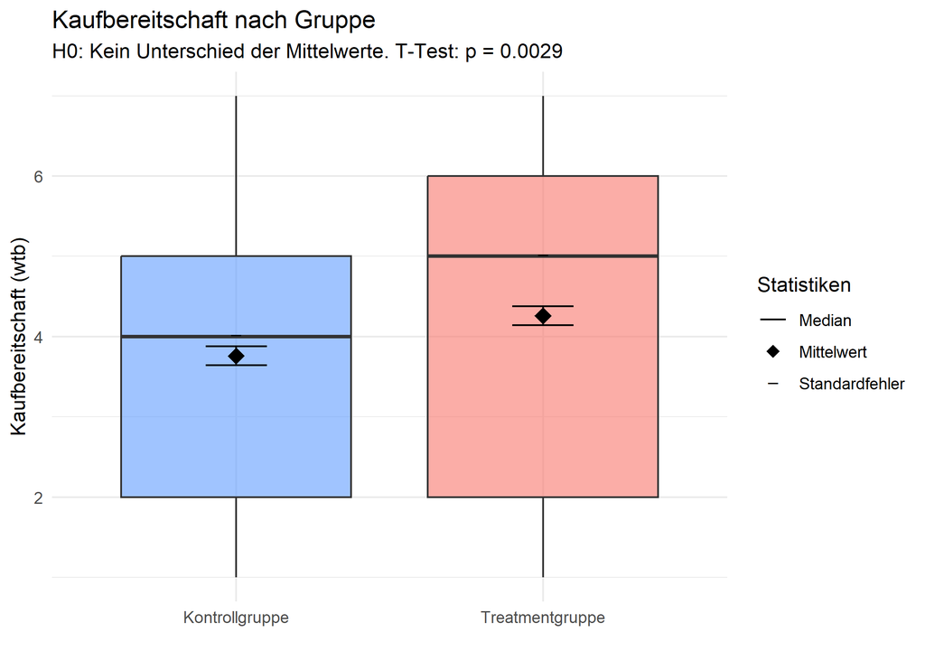

*Antwort:*

*Beschreibung:*

Die dargestellten Boxplots visualisieren die Verteilung der Kaufbereitschaft (wtb) in zwei experimentellen Gruppen: der Kontrollgruppe und der Treatmentgruppe. In der Kontrollgruppe (blau dargestellt) sahen die Teilnehmenden lediglich eine Standardverpackung ohne weiterführende Informationen zu den Produktionskosten. In der Treatmentgruppe (rot dargestellt) hingegen erhielten die Teilnehmenden zusätzlich transparente Informationen über die Zusammensetzung der Produktionskosten, beispielsweise für Zutaten, Verpackung und Arbeitsaufwand. Die y-Achse der Boxplots zeigt die Werte der Kaufbereitschaft auf einer Skala von 1 bis 7, wobei höhere Werte eine stärkere Bereitschaft zum Kauf der Schokolade anzeigen.

*Interpretation:*

Die dargestellten Unterschiede unterstützen die zentrale Hypothese des Experiments: Kostentransparenz erhöht die Kaufbereitschaft. Teilnehmer:innen, die Informationen über die einzelnen Bestandteile der Produktionskosten erhalten haben, waren eher bereit, das Produkt zu kaufen. Dies lässt sich psychologisch so deuten, dass die zusätzliche Information möglicherweise das Vertrauen in die Marke gestärkt hat. Transparente Kommunikation wirkt offenbar glaubwürdig, ehrlich und schafft Nähe zwischen Konsument:in und Unternehmen, was sich wiederum in einem höheren Kaufinteresse niederschlägt.

Diese Ergebnisse zeigen deutlich, dass die Offenlegung sensibler Unternehmensdaten wie Produktionskosten nicht abschreckend, sondern im Gegenteil vertrauensfördernd wirkt, ein Effekt, der sich messbar in der Kaufbereitschaft widerspiegelt.

Nachdem Sie nun die Differenzen in der Kaufabsicht zwischen der Treatment- und der Kontrollgruppe im zweiten Experiment überprüft und getestet haben, geht es im nächsten Schritt darum, den möglichen Mediator Vertrauen genauer zu untersuchen. Hierfür sollen Sie sich in einem ersten Schritt das Vertrauen der Personen allgemein anschauen, um einen Eindruck zu dieser wichtigen Variable zu bekommen. Dafür werden Personen anhand **hohem und niedrigem** Vertrauen und deren Kaufbereitschaft für das Produkt unterteilt.

10. Erstellen Sie eine oder mehrere geeignete Grafik(en), die den Zusammenhang zwischen Vertrauen (Trust) und der Kaufabsicht (WTB) **unabhängig** der beiden Treatment- und Kontrollgruppen darstellen. Achten Sie auf eine passende Darstellung der Informationen.

Die Grafik(en) sollen folgende Informationen enthalten:

- Unterteilen Sie ihre Daten in Personen mit `hohem` und `niedrigem` Vertrauen. Nutzen Sie für die Unterteilung den Median des Vertrauens in ihren Daten als Schwellenwert.
- Abhängig der Einstufungen in `hohes` und `niedriges` Vertrauen soll nun die durchschnittliche Kaufbereitschaft dargestellt werden. Hier soll die Grafik so dargestellt werden, dass auf der x-Achse das Vertrauensniveau (“hoch” und “niedrig”) und auf der y-Achse die entsprechende Kaufbereitschaft abgebildet wird.
- Berechnen Sie weiterhin die Mittelwerte der beiden Vertrauensgruppen und visualisieren diese in geeigneter Art und Weise in ihren Grafik(en).
- Führen Sie einen t-Test durch, um zu prüfen, ob die Mittelwertsunterschiede zwischen den beiden Vertrauensgruppen statistisch signifikant sind. Geben Sie den p-Wert in der Grafik an.

Beschreiben und interpretieren Sie ihre Grafik(en). Beantworten Sie insbesondere folgende Fragen:

- Welche Implikationen hat ein signifikanter Unterschied für die Rolle von Vertrauen auf Kaufentscheidungen?
- Wie stark unterscheidet sich die Kaufbereitschaft zwischen Personen mit hohem und niedrigem Vertrauen?
- Könnte auf Basis ihrer Darstellung Vertrauen als Mediator zwischen dem Treatment und der Kaufbereitschaft fungieren?

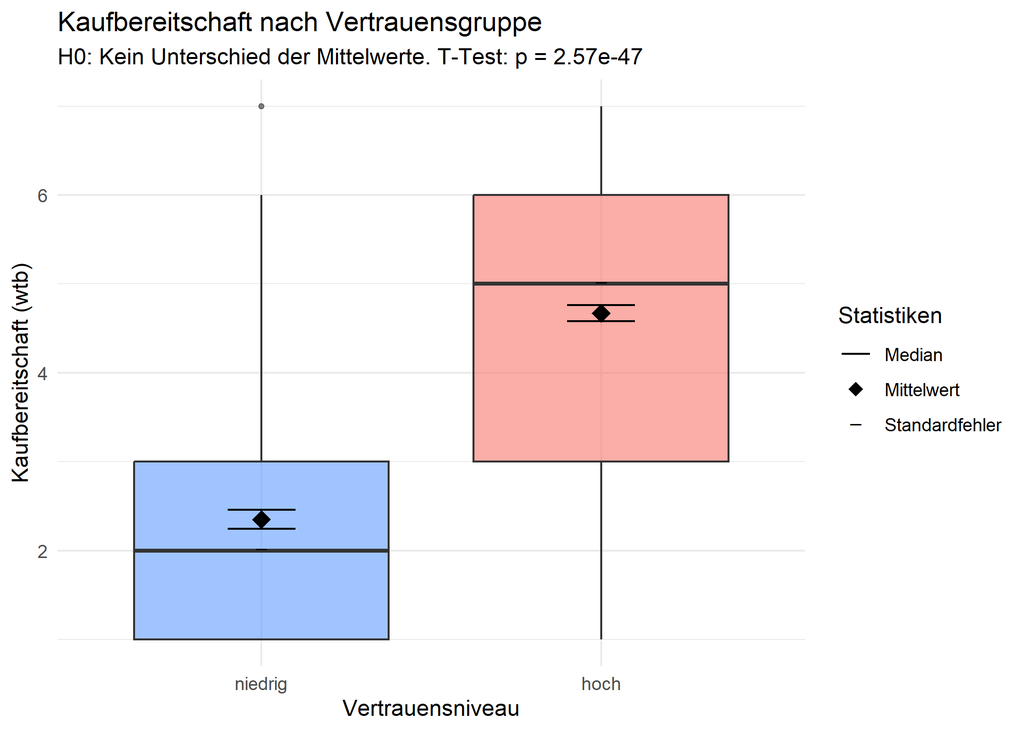

*Antwort:*

*Beschreibung:*

Die Grafik zeigt die Kaufbereitschaft (wtb) in Abhängigkeit vom Vertrauensniveau der Teilnehmenden, unabhängig davon, ob sie der Treatment- oder Kontrollgruppe zugewiesen waren. Die Unterteilung in „niedrig“ und „hoch“ basiert auf dem Medianwert der Variable Vertrauen (trust), Personen mit einem Vertrauenswert größergleich dem Median (= 5) wurden als „hoch“, jene darunter als „niedrig“ klassifiziert.

Auf der x-Achse sind die beiden Vertrauensgruppen („niedrig“ und „hoch“) dargestellt, auf der y-Achse die Kaufbereitschaft (wtb). Die Boxplots zeigen die Verteilung der Kaufbereitschaft innerhalb der beiden Gruppen:

-Die Gruppe mit hohem Vertrauen (rot) weist einen deutlich höheren Medianwert auf (bei 5), verglichen mit der Gruppe mit niedrigem Vertrauen (blau), bei der der Median bei 2 liegt.

-Auch die Mittelwerte (hier als schwarze Rauten dargestellt) bestätigen diesen Unterschied: Der durchschnittliche Wert liegt in der Hochvertrauensgruppe spürbar über dem der Niedrigvertrauensgruppe.

-Der angegebene p-Wert (p = 2.57e-47) stammt aus einem t-Test zur Prüfung des Mittelwertunterschieds. Er ist extrem klein und deutet auf einen hochsignifikanten Unterschied zwischen den beiden Gruppen hin.

*Interpretation:*

*Einfluss von Vertrauen auf die Kaufbereitschaft:*

Die Analyse zeigt, dass Personen mit höherem Vertrauen in das Unternehmen eine deutlich höhere Kaufbereitschaft aufweisen. Der Unterschied ist nicht nur visuell klar erkennbar, sondern auch statistisch hochsignifikant, was durch den extrem niedrigen p-Wert bestätigt wird. Vertrauen spielt also eine zentrale Rolle bei der Entscheidungsfindung von Konsument:innen.

*Stärke des Unterschieds:*

Der Unterschied in den zentralen Tendenzen (Median und Mittelwert) zeigt eine klare positive Korrelation zwischen Vertrauen und Kaufbereitschaft. Der Mittelwertsunterschied beträgt mehr als zwei ganze Punkte auf der Skala, was in sozialwissenschaftlichen Studien mit ähnlichen Skalen bereits als maßgeblich gilt.

*Vertrauen als potenzieller Mediator:*

Die Ergebnisse legen nahe, dass Vertrauen tatsächlich eine vermittelnde Variable (Mediator) zwischen der Informationstransparenz (Treatment) und der Kaufabsicht (wtb) sein könnte. Da in einem vorherigen Schritt gezeigt wurde, dass das Treatment das Vertrauen erhöht und hier nun belegt ist, dass Vertrauen die Kaufabsicht beeinflusst, ist eine Mediation durch Vertrauen theoretisch gut begründbar. Um dies endgültig zu klären, wäre jedoch eine formale Mediationsanalyse notwendig, zum Beispiel mit einem Regressionsmodell oder Bootstrapping.

*Fazit:*

Die Analyse liefert starke Hinweise darauf, dass Vertrauen ein zentraler psychologischer Mechanismus ist, über den sich die Wirkung von Kostentransparenz auf das Konsumverhalten entfalten kann. Je mehr Vertrauen Konsument:innen einem Unternehmen entgegenbringen, desto eher sind sie bereit, dessen Produkte zu kaufen.

# Regressionsanalyse

Sie haben nun ihren Datensatz kennengelernt und es scheint so, als ob insbesondere Personen, welche transparente Kosten sehen, dazu neigen, das Produkt zu kaufen. Doch um ihre deskriptiven Analysen zu erhärten, wollen Sie im folgenden eine Analyse mittels Regressionen durchführen.

11. Betrachten Sie hier noch einmal das erste Experiment (`daten_exp1`). Führen Sie eine Regression durch, bei der Ihnen `everlane` als abhängige Variable dient. Als erklärende Variable nutzen Sie das `treatment`. Erstellen sie eine weitere Regression, die zusätzlich noch für die folgenden Variablen kontrolliert:
- Alter
- Bildungsstufe
- Einkommen
- Geschlecht

Stellen Sie die Regressionsergebnisse in einer Tabelle mit stargazer oder modelsummary dar!

Beschreiben und interpretieren Sie ihre Ergebnisse. Gehen Sie insbesondere auf folgende Fragen ein:

- Lässt sich der Effekt des Treatments auf die Entscheidung der Kunden kausal interpretieren?
- Ist es wichtig auf weitere Faktoren zu kontrollieren?
- Beziehen Sie sich hier auch auf die Ergebnisse aus Aufgabe 5.

Regressions: Einfluss des Treatments auf Everlane-Wahl

|  | Ohne Kontrolle | Mit Kontrolle |
| --- | --- | --- |
| (Intercept) | 0.561*** | 0.647*** |
|  | (0.030) | (0.125) |
| Treatment | 0.154*** | 0.154*** |
|  | (0.043) | (0.043) |
| Alter |  | -0.002 |
|  |  | (0.002) |
| Bildung |  | -0.003 |
|  |  | (0.026) |
| Einkommen |  | -0.000 |
|  |  | (0.000) |
| Geschlecht (weiblich) |  | 0.079+ |
|  |  | (0.043) |
| Num.Obs. | 488 | 488 |
| R2 | 0.026 | 0.036 |
| R2 Adj. | 0.024 | 0.026 |
| AIC | 663.5 | 666.1 |
| BIC | 676.0 | 695.4 |
| Log.Lik. | -328.727 | -326.048 |
| F | 12.776 | 3.626 |
| RMSE | 0.47 | 0.47 |

+ p < 0.1, * p < 0.05, ** p < 0.01, *** p < 0.001

*Antwort:*

*Beschreibung:*

*Kausale Interpretierbarkeit des Behandlungseffekts:*

Der zentrale Vorteil experimenteller Studien liegt darin, dass durch die zufällige Zuteilung der Teilnehmenden zu Kontroll- und Treatmentgruppen mögliche Störfaktoren im Mittel ausgeglichen werden. In diesem Fall ist eine kausale Interpretation des Effekts des Treatments gerechtfertigt, da die Randomisierung erfolgreich war. Dies wird auch durch die Ergebnisse der Balancing-Tabelle aus Aufgabe 5 bestätigt, die zeigt, dass es keine signifikanten Unterschiede in den zentralen Kovariaten zwischen den beiden Gruppen gab (alle p-Werte > 0.05).

Das bedeutet: Der beobachtete Effekt auf die Everlane-Wahl ist mit hoher Wahrscheinlichkeit ursächlich auf das Treatment zurückzuführen und nicht auf vorbestehende Unterschiede zwischen den Gruppen.

*Notwendigkeit von Kontrollvariablen:*

Auch wenn Randomisierung theoretisch ausreicht, um Kausalität zu identifizieren, kann es praktisch sinnvoll sein, zusätzliche Kovariaten in die Analyse aufzunehmen. Der Grund dafür ist, dass die Kontrolle solcher Variablen die Schätzung präziser macht, indem unerklärte Varianz reduziert wird. Zudem dient sie der Robustheitsprüfung: Wenn der Effekt auch nach Einbezug weiterer Variablen bestehen bleibt, wie es hier der Fall ist, stärkt dies die Aussagekraft der Ergebnisse. Darüber hinaus ermöglicht die Kontrolle zusätzlicher Variablen explorative Einsichten. In diesem Fall zeigt sich zum Beispiel, dass weibliche Teilnehmende eine höhere Wahrscheinlichkeit haben, das Everlane-Produkt zu wählen – ein interessanter zusätzlicher Befund.

*Bezug zur Balancing-Tabelle (Aufgabe 5):*

Die Balancing-Tabelle in Aufgabe 5 zeigt, dass sich Kontroll- und Treatmentgruppen nicht signifikant hinsichtlich Alter, Geschlecht, Einkommen oder Bildung unterscheiden. Die Differenzen sind durchweg klein und statistisch unbedeutend. Dies bestätigt die Erfolgreichkeit der Randomisierung und stärkt die Annahme, dass systematische Verzerrungen durch unbeobachtete Störfaktoren unwahrscheinlich sind. Somit lässt sich der Effekt des Treatments mit hoher Sicherheit als kausaler Einfluss interpretieren, und nicht als Ergebnis bestehender Unterschiede zwischen den Gruppen.

Während die bisherigen Analysen zeigen, dass das Treatment einen Effekt hat, stellt sich nun die Frage, warum das so ist. Nun sollten Sie im weiteren Verlauf durch vertiefende Regressionsanalysen prüfen, ob dies auf das Vertrauen der Kunden zurückzuführen ist. Dazu betrachten Sie noch einmal den Datensatz zu Experiment 2 (`daten_exp2`) und untersuchen, ob das Treatment (Kunden sehen transparente Kostenstruktur) zu einer höheren Kaufabsicht führt, weil sie das Vertrauen der Konsumenten in das Unternehmen stärkt.

12. Schauen Sie sich den Einfluss der Kostentransparenz auf die Kaufabsicht in den folgenden zwei Regressionen genauer an und zeigen Sie ihre Ergebnisse nebeneinander:

**1. Regression:** Abhängige Variable ist die Kaufabsicht; die erklärende Variable ist das Treatment.

**2. Regression:** Wie in der 1. Regression, doch kontrollieren Sie hier zusätzlich auf die Variablen Alter, Einkommensniveau, Bildungsstufe und Geschlecht.

Stellen Sie die Regressionsergebnisse in einer Tabelle mit stargazer oder modelsummary dar!

Beschreiben und interpretieren Sie ihre Ergebnisse allgemein. Gehen Sie weiterhin auch speziell auf folgende Fragen ein:

- Sollten die Kontrollvariablen in ihrer zweiten Regression den Koeffizienten des Treatments ändern? Was würden Sie erwarten und warum? Nutzen Sie hierzu die Ergebnisse aus Aufgabe 8.
  - Vergleichen Sie die Regressionskoeffizienten der Treatment-Variable in der ersten und zweiten Regression. Gibt es hier einen signifikanten Unterschied in der Größe des Effekts?
- Bringt ihnen die Regression Vorteile gegenüber einer reinen Darstellung der Mittelwerte wie in Aufgabe 9?
- Ist der Effekt des Treatments auf die Kaufabsicht ihrer Ansicht nach kausal interpretierbar?
  - Welche Voraussetzungen müssen erfüllt sein, damit man diesen Regressionskoeffizienten als kausalen Effekt interpretieren kann?
  - Überlegen Sie sich, wie sich das Ergebnis verändern würde, wenn zusätzlich Vertrauen (trust) in das Modell aufgenommen wird. Würde sich der Effekt von `treatment` verändern? Warum oder warum nicht?

Hier bitte ihren **Code und** ihre **Antwort** eintragen

Regression: Einfluss des Treatments auf Kaufabsicht (WTB)

|  | Ohne Kontrolle | Mit Kontrolle |
| --- | --- | --- |
| (Intercept) | 3.760*** | 3.782*** |
|  | (0.119) | (0.449) |
| Treatment | 0.501** | 0.454** |
|  | (0.167) | (0.169) |
| Alter |  | -0.015+ |
|  |  | (0.008) |
| Einkommen |  | 0.000 |
|  |  | (0.000) |
| Bildung |  | 0.131 |
|  |  | (0.102) |
| Geschlecht (weiblich) |  | 0.062 |
|  |  | (0.171) |
| Num.Obs. | 583 | 583 |
| R2 | 0.015 | 0.024 |
| R2 Adj. | 0.013 | 0.016 |
| AIC | 2478.9 | 2481.5 |
| BIC | 2492.0 | 2512.1 |
| Log.Lik. | -1236.472 | -1233.746 |
| F | 8.940 | 2.877 |
| RMSE | 2.02 | 2.01 |

+ p < 0.1, * p < 0.05, ** p < 0.01, *** p < 0.001

*Antwort:*

*Beschreibung und Interpretation:*

In den beiden durchgeführten Regressionen wird der Einfluss des Treatments auf die Kaufabsicht (wtb) untersucht. Im ersten Modell wird nur der Treatment-Effekt geschätzt, im zweiten Modell werden zusätzlich die Kontrollvariablen Alter, Einkommen, Bildung und Geschlecht berücksichtigt. Der Koeffizient für das Treatment ist in beiden Modellen positiv und statistisch signifikant (p < 0.01), was darauf hindeutet, dass die Information über transparente Kosten die Kaufbereitschaft der Kunden im Durchschnitt erhöht. Die Größe des Effekts sinkt leicht von 0.501 im einfachen Modell auf 0.454 im kontrollierten Modell, bleibt aber stabil und signifikant. Die Kontrollvariablen zeigen insgesamt keine statistisch signifikanten Effekte auf die Kaufabsicht. Der Einfluss der Bildung ist zwar positiv, erreicht jedoch kein Signifikanzniveau und der Einfluss des Alters ist nur minimal negativ.

*Sollten Kontrollvariablen den Treatment-Koeffizienten verändern? (Vergleich zu Aufgabe 8)*

Aus der Balancing-Tabelle in Aufgabe 8 wissen wir, dass es im Datensatz nur geringe und meist statistisch nicht signifikante Unterschiede in den Kontrollvariablen zwischen Treatment- und Kontrollgruppe gibt (Ausnahme: Alter, das signifikant niedriger in der Treatmentgruppe ist). Daher würde man erwarten, dass die Einbeziehung dieser Variablen in die Regression den Treatment-Koeffizienten kaum verändert, da die Gruppen vor der Behandlung im Wesentlichen vergleichbar sind und Unterschiede nicht systematisch die Kaufabsicht beeinflussen. Der leichte Rückgang des Koeffizienten von 0.501 auf 0.454 bestätigt diese Erwartung. Es gibt keinen signifikanten Unterschied in der Größe des Effekts zwischen den beiden Modellen. Die Kontrollvariablen korrigieren hier mögliche kleine Verzerrungen, verändern das Ergebnis jedoch kaum.

*Vorteile der Regression gegenüber reinen Mittelwertvergleichen (Aufgabe 9)*

Die Regression bietet gegenüber der rein deskriptiven Darstellung in Aufgabe 9 mehrere Vorteile:

- Erstens die Berücksichtigung von Kovariaten: Die Regression kann systematisch den Einfluss von Störfaktoren (Alter, Bildung, Einkommen, Geschlecht) kontrollieren und so einen präziseren Effekt des Treatments schätzen.
- Zweitesns die Schätzung von Standardfehlern und Signifikanz: Die Regression liefert formale Tests und Konfidenzintervalle, die den statistischen Nachweis des Treatment-Effekts absichern.
- Und drittens Flexibilität: Die Methode ermöglicht einfache Erweiterungen (z.B. Einbeziehung von Mediatoren oder Interaktionen).

In Aufgabe 9 zeigt der Boxplot bereits signifikante Unterschiede zwischen Gruppen, doch die Regression bestätigt diese Effekte robust unter Kontrolle anderer Variablen.

*Kausale Interpretation des Treatment-Effekts auf die Kaufabsicht:*

In dem durchgeführten Experiment wurde die Randomisierung eingehalten, und die Analyse der Kontrollvariablen in der Regression zeigt, dass diese kaum Einfluss nehmen. Daher kann der Treatment-Koeffizient überzeugend als kausaler Effekt des Treatments auf die Kaufabsicht interpretiert werden. Dies ermöglicht die Schlussfolgerung, dass Änderungen in der Kaufabsicht tatsächlich auf das Treatment zurückzuführen sind und nicht auf externe oder unbeobachtete Faktoren.

*Einfluss von Vertrauen (trust) als möglicher Mediator:*

Wird die Variable “trust” in die Regression aufgenommen, könnte dies den Effekt des Treatments auf die Kaufabsicht verändern. Die vermutete Mediation würde bedeuten, dass das Treatment die Kaufabsicht der Teilnehmer dadurch erhöht, dass es das Vertrauen der Kunden stärkt. In einem solchen Fall wäre Vertrauen (trust) die vermittelnde Variable. Wenn Vertrauen tatsächlich eine solche Rolle spielt, würde sich der direkte Effekt des Treatments auf die Kaufabsicht verringern, sobald Vertrauen in die Analyse einbezogen wird. Das würde sich in einem signifikanten Rückgang des Treatment-Koeffizienten nach der Einbeziehung von Vertrauen zeigen, was die Hypothese unterstützt, dass Vertrauen als Mediator den Effekt des Treatments vermittelt. Andererseits, wenn der Effekt des Treatments stabil bleibt, nachdem Vertrauen in die Regression aufgenommen wurde, deutet dies darauf hin, dass der Einfluss des Treatments auf die Kaufabsicht nicht (allein) durch Vertrauen vermittelt wird. Somit würde Vertrauen in diesem Fall nicht als Mediator wirken, und andere Faktoren könnten den beobachteten Effekt erklären. Diese Analyse kann helfen, die Mechanismen zu verstehen, durch die das Treatment die Kaufabsicht beeinflusst.

Sie haben nun gesehen, dass es auch hier einen direkten Effekt des Treatments (transparente Kostenstrukur) auf die Kaufabsicht gibt. Doch um die dahinter liegenden Mechanismen zu verstehen, müssen Sie tiefer in psychologische Prozesse eintauchen. Experiment 2 zeigt dafür ein entsprechendes Design, um zu testen, ob Vertrauen als vermittelnder Mechanismus eine Rolle spielt. Im nächsten Schritt analysieren Sie nun selbst diese Beziehung mit theoretischen Modellen und Regressionsmethoden, um ein Gefühl dafür zu bekommen, wie sich direkte und indirekte Effekte voneinander unterscheiden.

13. Bevor Sie im nächsten Schritt ein konkretes DAG zu einem psychologischen Mediationsmechanismus erstellen, machen Sie sich zunächst mit den theoretischen Grundlagen von Directed Acyclic Graphs (DAGs) vertraut. DAGs (gerichtete azyklische Graphen) sind ein nützliches Werkzeug in der Kausalanalyse.

Beantworten Sie folgende theoretische Fragen zu DAGs:

- Wofür werden DAGs in der empirischen Forschung verwendet?
- Nennen und beschreiben Sie zwei zentrale Knotentypen in einem DAG: Confounder und Mediator.
- Worin besteht der zentrale Unterschied, ob Vertrauen als Kontrollvariable (Confounder) oder als Mediator behandelt wird - und warum ist Letzteres entscheidend für das Verständnis psychologischer Prozesse im vorliegenden Experiment?

*Antwort:*

*Verwendung von Directed Acyclic Graphs (DAGs) in der empirischen Forschung:*

Directed Acyclic Graphs, kurz DAGs, sind ein zentrales Werkzeug in der Kausalanalyse innerhalb der empirischen Forschung. Sie bieten eine visuelle Darstellung von kausalen Beziehungen zwischen verschiedenen Variablen, indem sie aufzeigen, wie diese Variablen miteinander in Beziehung stehen. Die gerichteten Kanten in einem DAG repräsentieren kausale Einflüsse, während die azyklische Struktur sicherstellt, dass keine Schleifen existieren. Damit ist gemeint, dass eine Variable nicht indirekt auf sich selbst zurückwirkt. DAGs sind hilfreich, um kausale Hypothesen zu illustrieren und zu überprüfen. Sie unterstützen Forscher dabei, potenzielle Quellen von Verzerrungen, wie etwa Confounding oder Mediation, zu identifizieren und die Struktur kausaler Pfade zu verstehen. Zudem helfen DAGs bei der Identifikation relevanter Kontrollvariablen, um Verzerrungen in der Analyse zu vermeiden.

*Zentrale Knotentypen in einem DAG: Confounder und Mediator:*

In Directed Acyclic Graphs gibt es zwei zentrale Knotentypen, die in der Kausalanalyse von Bedeutung sind: Confounder und Mediator. Ein Confounder ist eine Variable, die sowohl einen Einfluss auf die unabhängige Variable als auch auf die abhängige Variable hat. Falls nicht kontrolliert, kann ein Confounder zu einer verzerrten Schätzung der kausalen Beziehung zwischen zwei anderen Variablen führen, da er einen Scheinzusammenhang erzeugen kann. Ein Mediator hingegen ist eine Variable, die den kausalen Einfluss von einer unabhängigen Variable auf eine abhängige Variable vermittelt oder erklärt. In einem kausalen Pfad wird der Effekt der unabhängigen Variable durch den Mediator zur abhängigen Variable geleitet. Der Mediator spielt somit eine wesentliche Rolle im Verständnis, wie oder warum ein bestimmter kausaler Zusammenhang besteht.

*Vertrauen als Kontrollvariable oder Mediator: Der zentrale Unterschied:*

Bei der Analyse von kausalen Zusammenhängen ist es entscheidend, den Unterschied zwischen einer Kontrollvariable (Confounder) und einem Mediator zu verstehen, insbesondere anhand der Variable Vertrauen. Wird Vertrauen als Kontrollvariable betrachtet, bedeutet dies, dass es als Confounder eine Rolle spielt. In diesem Fall beeinflusst Vertrauen sowohl das Treatment als auch die Kaufabsicht. Vertrauen als Controlvariable könnte also außerhalb der spezifischen Behandlung der transparenten Kostenstruktur stehen und könnte bei Nichtkontrolle Verzerrungen in der Schätzung des direkten Effekts verursachen. Wird Vertrauen jedoch als Mediator betrachtet, vermittelt es die Beziehung zwischen dem Treatment und der Kaufabsicht. Es nimmt eine vermittelnde Rolle ein, indem es erklärt, wie die Wirkung des Treatments die Kaufabsicht beeinflusst. Diese Rolle von Vertrauen ist entscheidend für das Verständnis psychologischer Prozesse, da sie tiefergehende Einblicke in die Mechanismen einer Verhaltensänderung durch das Treatment bietet. Die Unterscheidung zwischen Vertrauen als Kontrollvariable und als Mediator ist wesentlich, um ein präzises kausales Modell zu entwickeln, das nicht nur den Effekt quantifiziert, sondern auch erklärt, welche psychologischen oder verhaltensmäßigen Mechanismen beteiligt sind.

14. Nutzen Sie nun das Directed Acyclic Graph (DAG), um die Beziehungen zwischen den Variablen Treatment (T), Vertrauen (V) und Kaufbereitschaft (K) zu analysieren und den vermuteten Mediationsmechanismus zu untersuchen.

Beschreiben und interpretieren Sie ihr DAG und die Beziehungen zwischen den Variablen. Gehen Sie insbesondere auf folgende Fragen und Aspekte ein:

- Begründen und erklären Sie die Struktur und den Aufbau ihres DAGs.
- Welche Annahmen müssen getroffen werden, damit Vertrauen tatsächlich als Mediator interpretiert werden kann?
- Welche Verzerrungen oder Störfaktoren könnten den Mediator-Effekt von Vertrauen beeinflussen? Wie könnte dies die Ergebnisse verzerren?

*Hinweis 1:* Für die Erstellung des DAGs können Sie das Paket `dagify` verwenden. Als Grundlage und Hilfsmittel können Sie die Vorlesungsfolien nutzen.

*Hinweis 2:* Eine direkte Visualisierung des DAGs in `R` ist schön, aber keine Pflicht. Sie können das DAG auch in Word/PowerPoint zeichnen und ihre Grafik mittels `include_graphics()` einfügen.

[interactive chart not shown]

*Antwort:*

*Beschreibung und Interpretation des DAGs:*

Der Directed Acyclic Graph (DAG) visualisiert die Beziehungen zwischen den Variablen Treatment , Vertrauen und Kaufbereitschaft. In diesem DAG wird angenommen, dass das Treatment sowohl direkt als auch indirekt die Kaufbereitschaft beeinflusst. Der indirekte Pfad verläuft über Vertrauen als Mediator. Die Struktur des DAGs zeigt die Hypothese, dass das Treatment das Vertrauen der Teilnehmer stärkt, was wiederum die Kaufbereitschaft erhöht. Gleichzeitig wird ein direkter Einfluss des Treatments auf die Kaufbereitschaft unterstellt.

*Begründung und Erklärung der Struktur:*

Die Struktur des DAGs repräsentiert eine typische Mediator-Hypothese in der kausalen Analyse. Der Pfeil vom Treatment zu Vertrauen zeigt an, dass das Treatment das Vertrauen beeinflusst. Der Pfeil von Vertrauen zu Kaufbereitschaft deutet darauf hin, dass Vertrauen die Kaufbereitschaft beeinflusst. Der direkte Pfeil von Treatment zu Kaufbereitschaft stellt sicher, dass wir den Effekt des Treatments auf die Kaufbereitschaft, der nicht durch Vertrauen vermittelt wird, ebenfalls in Betracht ziehen.

*Annahmen für Vertrauen als Mediator:**

Damit Vertrauen als Mediator interpretiert werden kann, müssen einige Annahmen getroffen werden:

- Kausalität: Es muss kausal gerechtfertigt sein, dass das Treatment einen Einfluss auf Vertrauen hat, und dass Vertrauen einen kausalen Einfluss auf die Kaufbereitschaft hat.
- Exklusivität: Vertrauen sollte nicht durch andere unbeobachtete Variablen beeinflusst werden, die sowohl mit dem Treatment als auch der Kaufbereitschaft assoziiert sind.
- Richtung der Effekte: Es muss sichergestellt werden, dass der Effekt des Treatments auf die Kaufbereitschaft zumindest teilweise durch Vertrauen vermittelt wird.

*Verzerrungen und Störfaktoren:*

Mehrere Verzerrungen oder Störfaktoren könnten den Mediator-Effekt von Vertrauen beeinflussen:

- Third Variable Bias: Wenn es eine unbeobachtete Variable gibt, die sowohl Vertrauen als auch die Kaufbereitschaft beeinflusst, könnte das zu einem Schein-Zusammenhang führen.
- Nicht-Gemessene Variablen: Möglicherweise existieren andere relevante Variablen, die nicht gemessen wurden und die Rolle von Vertrauen als Mediator maskieren könnten.
- Fehlende Kontrollvariablen: Wenn andere relevante Variablen, die sowohl das Treatment als auch die Kaufbereitschaft beeinflussen, nicht kontrolliert werden, könnten die Schätzungen verzerrt sein.

Diese Verzerrungen könnten dazu führen, dass der Einfluss des Vertrauen-Mediators überschätzt oder unterschätzt wird. Eine mögliche Lösung wäre, sorgfältig alle möglichen Störgrößen zu identifizieren und durch zusätzliche Kontrollvariablen zu erfassen. Der Einsatz von robusten statistischen Techniken wie Sensitivitätsanalysen könnte ebenfalls helfen, Verzerrungen zu mindern.

15. Führen Sie nun eine Regression durch, bei der Ihnen `trust` (Vertrauen) als abhängige Variable dient. Weiterhin soll ihnen `treatment` als erklärende Variable dienen. Erstellen sie eine weitere Regression, die zusätzlich noch für die folgenden Variablen kontrolliert: Alter, Einkommensniveau, Bildungsstufe und ob die Personen weiblich sind.

Stellen Sie die Regressionsergebnisse in einer Tabelle mit stargazer oder modelsummary dar!

Beschreiben und interpretieren Sie ihre Ergebnisse. Gehen Sie bei der Interpretation der Ergebnisse insbesondere auf folgende Fragen ein:

- Macht es ihrer Ansicht nach Sinn auf die zusätzlichen Variablen in Regression 2 zu kontrollieren? Worauf müssen Sie besonders achten?
- Was bedeutet ein signifikanter positiver Koeffizient für treatment in Bezug auf Vertrauen?
- Warum ist dieser Pfad (Treatment ➝ Trust) notwendig, damit eine Mediation überhaupt möglich ist?
- Überlegen Sie, ob andere Faktoren, die Sie möglicherweise nicht berücksichtigt haben, diesen Zusammenhang ebenfalls erklären könnten.

Regression: Einfluss des Treatments auf Vertrauen (trust)

|  | Ohne Kontrolle | Mit Kontrolle |
| --- | --- | --- |
| (Intercept) | 4.830*** | 4.624*** |
|  | (0.081) | (0.305) |
| Treatment | 0.455*** | 0.438*** |
|  | (0.114) | (0.115) |
| Alter |  | -0.001 |
|  |  | (0.005) |
| Einkommen |  | -0.000 |
|  |  | (0.000) |
| Bildung |  | 0.065 |
|  |  | (0.069) |
| Geschlecht (weiblich) |  | 0.206+ |
|  |  | (0.116) |
| Num.Obs. | 583 | 583 |
| R2 | 0.027 | 0.035 |
| R2 Adj. | 0.025 | 0.026 |
| AIC | 2028.9 | 2032.0 |
| BIC | 2042.0 | 2062.6 |
| Log.Lik. | -1011.444 | -1009.018 |
| F | 15.974 | 4.164 |
| RMSE | 1.37 | 1.37 |

+ p < 0.1, * p < 0.05, ** p < 0.01, *** p < 0.001

*Antwort:*

*Beschreibung:*

In beiden Regressionsmodellen wird der Einfluss des Treatments auf das Vertrauen der Konsument:innen untersucht. In Modell 1 wird lediglich der Treatment-Effekt geschätzt, während Modell 2 zusätzlich Kontrollvariablen wie Alter, Einkommen, Bildung und Geschlecht berücksichtigt. In beiden Modellen ist der Koeffizient für die Treatment-Variable signifikant positiv und liegt bei etwa 0.45. Das bedeutet: Personen, die transparente Kosteninformationen sehen (Treatment-Gruppe), berichten im Durchschnitt ein um etwa 0.45 Punkte höheres Vertrauen in das Unternehmen (Skala 1–7) als Personen in der Kontrollgruppe, selbst nach Kontrolle für demografische Merkmale. Die Kontrollvariablen selbst zeigen keinen signifikanten Einfluss auf das Vertrauen, was darauf hindeutet, dass die demografischen Faktoren in diesem Zusammenhang nur eine untergeordnete Rolle spielen. Die Modellgüte ist insgesamt gering (R² ≈ 0.03), was bei psychologischen Konstrukten wie Vertrauen allerdings nicht ungewöhnlich ist.

*Interpretation:*

*Sinn der Kontrollvariablen, worauf ist zu achten?:*

Es macht grundsätzlich Sinn, zusätzliche Variablen wie Alter, Einkommen, Bildung und Geschlecht in Regression 2 zu kontrollieren, da diese theoretisch mit Vertrauen korrelieren könnten. Besonders wichtig ist jedoch:

- Die Treatment-Zuweisung erfolgte experimentell, also randomisiert. Dadurch sind systematische Unterschiede zwischen den Gruppen unwahrscheinlich.
- Kontrollvariablen sind also nicht notwendig, um den Effekt korrekt zu schätzen, können aber die Präzision verbessern oder Störfaktoren ausschließen, falls doch zufällige Imbalancen bestehen (siehe Aufgabe 8).
- Wichtig: Wenn man eine Mediator-Variable wie Vertrauen analysieren möchte, dürfen keine Variablen kontrolliert werden, die auf dem Kausalweg zwischen Treatment und Vertrauen liegen, da dies zu Verzerrungen führen kann.

*Bedeutung des positiven Treatment-Koeffizienten:*

Ein signifikanter positiver Koeffizient für treatment bedeutet: Das Vertrauen in das Unternehmen steigt, wenn den Kund:innen eine transparente Kostenstruktur gezeigt wird. Dieser Effekt ist robust gegenüber der Kontrolle anderer Variablen, was für eine klare Beziehung zwischen Treatment und Vertrauen spricht. Inhaltlich legt das nahe, dass Transparenz als vertrauensfördernd wirkt, ein zentraler psychologischer Mechanismus, um Konsument:innen positiv zu stimmen.

*Warum dieser Pfad notwendig für eine Mediation ist:*

In der Logik einer Mediationsanalyse muss der Pfad Treatment ➝ Vertrauen statistisch signifikant sein, damit Vertrauen überhaupt als vermittelnder Mechanismus in Frage kommt. Nur wenn das Treatment einen Einfluss auf Vertrauen hat, kann Vertrauen wiederum einen Einfluss auf die Kaufabsicht ausüben und somit als Mediator fungieren. Wäre dieser Pfad nicht signifikant, würde das bedeuten, dass Vertrauen nicht durch das Treatment beeinflusst wird, also eine Mediation ausgeschlossen wäre.

*Gibt es alternative Erklärungen für den Zusammenhang?:*

Ja, auch wenn das Treatment randomisiert wurde, können nicht beobachtete Variablen den Zusammenhang potenziell beeinflussen:

Beispielsweise könnten individuelle Wertehaltungen (z. B. „Wertschätzung von Ehrlichkeit“) oder vorbestehende Einstellungen zu Nachhaltigkeit oder Fairness eine Rolle spielen. Außerdem könnten auch kontextuelle Effekte (z. B. wie glaubwürdig die Kostenangaben wahrgenommen wurden) das Vertrauen mitbestimmen. Zudem kann es sein, dass Verständnis oder Interesse an Kosteninformationen unterschiedlich ausgeprägt sind und dies wiederum Vertrauen beeinflusst.

Solche nicht beobachteten Confounder könnten die Interpretation des Effekts etwas einschränken – allerdings ist dies bei experimentellen Designs typischerweise weniger problematisch als bei rein beobachtenden Studien.

*Fazit:*

Die Ergebnisse zeigen klar: Transparenz fördert Vertrauen und dieser Zusammenhang ist statistisch signifikant und robust gegenüber der Kontrolle weiterer Variablen. Damit ist eine zentrale Voraussetzung für eine psychologische Mediation über Vertrauen erfüllt. Weitere Analysen können nun klären, ob Vertrauen wiederum die Kaufabsicht beeinflusst – und ob damit ein indirekter Effekt des Treatments besteht.

16. Nachdem Sie nun den Effekt des Treatments auf das Vertrauen geschätzt und ausgewertet haben, sollen Sie nun testen, ob das Vertrauen als Mediator zwischen Treatment und Kaufabsicht wirkt.

Führen Sie eine Regression durch, bei der Ihnen die Kaufbereitschaft als abhängige Variable dient. Weiterhin sollen die erklärende Variablen nun `treatment`, sowie das Vertrauen (`trust`) umfassen. Erstellen sie eine weitere Regression, die zusätzlich noch auf Alter, Einkommensniveau, Bildungsstufe und ob die Personen weiblich sind, kontrolliert.

Stellen Sie die Regressionsergebnisse passend in einer Tabelle dar!

Beschreiben und interpretieren Sie ihre Ergebnisse. Gehen Sie bei der Interpretation der Ergebnisse insbesondere auf folgende Fragen ein:

- Was könnten Ihrer Ansicht nach Gründe sein, dass `treatment` jetzt nicht mehr signifkant ist? Woran könnt das im Detail liegen?
- Warum ist es wichtig, `trust` und `treatment` gemeinsam in einem Modell zu betrachten?
- Warum könnte `trust` eine “notwendige Bedingung” sein, damit Transparenz der Kostenstruktur zu höherer Kaufbereitschaft führt?

Regression: Vertrauen als Mediator zwischen Treatment und Kaufabsicht

|  | Ohne Kontrolle | Mit Kontrolle |
| --- | --- | --- |
| (Intercept) | -0.178 | -0.008 |
|  | (0.265) | (0.441) |
| Treatment | 0.130 | 0.095 |
|  | (0.141) | (0.142) |
| Vertrauen | 0.815*** | 0.820*** |
|  | (0.051) | (0.051) |
| Alter |  | -0.014* |
|  |  | (0.006) |
| Einkommen |  | 0.000 |
|  |  | (0.000) |
| Bildung |  | 0.078 |
|  |  | (0.085) |
| Geschlecht (weiblich) |  | -0.108 |
|  |  | (0.142) |
| Num.Obs. | 583 | 583 |
| R2 | 0.318 | 0.327 |
| R2 Adj. | 0.315 | 0.320 |
| AIC | 2266.9 | 2266.5 |
| BIC | 2284.4 | 2301.5 |
| Log.Lik. | -1129.455 | -1125.275 |
| F | 135.079 | 46.748 |
| RMSE | 1.68 | 1.67 |

+ p < 0.1, * p < 0.05, ** p < 0.01, *** p < 0.001

*Antwort:*

*Beschreibung*

*Interpretation:*

*Gründe für das Fehlen der Signifikanz des Treatments:*

In den durchgeführten Regressionen zeigt sich, dass der Koeffizient für das Treatment weder in Modell (1) noch in Modell (2) signifikant ist. Das deutet darauf hin, dass die Transparenz allein keinen eindeutigen Einfluss auf die Kaufabsicht hat, insbesondere wenn Vertrauen als erklärende Variable berücksichtigt wird. Mögliche Gründe hierfür könnten eine vermittelnde Rolle von Vertrauen sein, wodurch der direkte Einfluss des Treatments auf die Kaufabsicht verringert wird. Vertrauen als starker Mediator könnte den Effekt des Treatments überlagern, was zu der beobachteten Reduktion in der Signifikanz führt. Ein weiterer Grund könnte in der unvollständigen Messung oder Modellierung der Daten liegen. Möglicherweise wurden nicht alle relevanten Einflussfaktoren in die Analyse einbezogen, oder es besteht eine unzureichende Differenzierung in den Daten.

*Bedeutung der gleichzeitigen Betrachtung von Vertrauen und Treatment:*

Die gleichzeitige Betrachtung von Vertrauen (trust) und Treatment in einem Modell ist entscheidend, um die Mechanismen zu verstehen, durch die das Treatment die Kaufbereitschaft beeinflussen könnte. Vertrauen zeigt in beiden Modellen einen hoch signifikanten Einfluss auf die Kaufabsicht, was darauf hindeutet, dass die Wirkung des Treatments zu einem großen Teil über den Mechanismus von Vertrauen vermittelt wird. Ohne die Einbeziehung von Vertrauen könnte leicht übersehen werden, wie das Treatment tatsächlich wirkt, und es würde zu einer unvollständigen Analyse des Entscheidungsprozesses der Verbraucher führen. Die Berücksichtigung von Vertrauen erlaubt daher eine tiefere und umfassendere Analyse der dynamischen Beziehungen, die im Spiel sind.

*Vertrauen als notwendige Bedingung für den Erfolg des Treatments:*

Vertrauen könnte als notwendige Bedingung verstanden werden, damit die Transparenz der Kostenstruktur tatsächlich zu einer höheren Kaufbereitschaft führt. Vertrauen fungiert als eine vermittelnde Komponente, durch die die Klarheit und Offenheit in der Kommunikation der Kostenstruktur die Wahrnehmung und Einstellungen der Kunden positiv beeinflusst. Ohne das fundamentale Vertrauen darin, dass die präsentierten Informationen korrekt und zum Vorteil der Kunden sind, könnten die Bemühungen um Transparenz ihre beabsichtigte Wirkung nicht entfalten. Als Grundlage für Entscheidungsprozesse der Kunden ist Vertrauen entscheidend, um den erfolgreichen Transfer des beabsichtigten Transparenzeffekts auf das Kaufverhalten sicherzustellen. Diese Erkenntnis betont die Notwendigkeit, in Kundenkommunikation und -strategien das Vertrauen systematisch zu stärken, um wirkungsvolle Ergebnisse zu erzielen.

In den vorangegangenen Modellen wurde untersucht, ob das Treatment (Kostentransparenz) das Vertrauen in das Unternehmen beeinflusst und ob Vertrauen wiederum mit der Kaufabsicht zusammenhängt.

17. Bewerten Sie das experimentelle Design der Studie 2. Gehen Sie dabei auch darauf ein, inwiefern Ihre Ergebnisse aus Aufgabe 13 bis 16 das theoretische Verständnis von Vertrauensbildung in der Konsumentenpsychologie bestätigt oder infrage stellt. Welche Stärken und Schwächen sehen Sie bezüglich der internen Validität und der Kausalitätsaussagen? Diskutieren Sie zudem kurz, inwiefern die Ergebnisse auf andere Bevölkerungsgruppen oder kulturelle Kontexte übertragbar sind.

*Hinweis:* Informationen zum Verständnis der Vertrauensbildung in der Konsumentenpsychologie können Sie [in dem folgenden Artikel](https://www.shs-conferences.org/articles/shsconf/pdf/2021/26/shsconf_appsconf2021_03019.pdf) auf Seite 2 bis 5 nachlesen.

Das experimentelle Design der zweiten Studie ist solide und erlaubt durch die Randomisierung der Treatment-Zuweisung eine kausale Interpretation der beobachteten Effekte. Durch die gezielte Manipulation der Kostentransparenz und die anschließende Messung psychologischer Konstrukte wie Vertrauen und Kaufbereitschaft wird ein typisches Mediationsdesign realisiert.

*Stärken:*

*Hohe interne Validität:*

Die zufällige Zuweisung der Teilnehmer:innen zu den Experimentalgruppen (Treatment vs. Kontrollgruppe) verhindert systematische Verzerrungen. Dadurch ist sichergestellt, dass beobachtete Unterschiede im Vertrauen oder der Kaufabsicht auf das Treatment zurückzuführen sind.

*Kausalanalyse mittels DAG und Regressionen:*

Die Aufgaben 13–16 zeigen, dass Vertrauen als Mediator zwischen Treatment und Kaufabsicht plausibel modelliert werden kann. Der signifikante Pfad von Treatment → Vertrauen (Aufgabe 15) und Vertrauen → Kaufabsicht (Aufgabe 16) stützt die Mediationsannahme und liefert psychologische Erklärungsansätze.

*Methodenvielfalt:*

Die Kombination aus theoretischen Modellen (z.B. DAG), quantitativer Analyse (Regressionsmodelle mit Kontrollvariablen) und psychologischen Konzepten (Vertrauen als Mechanismus) ermöglicht eine differenzierte Betrachtung der Wirkung von Kostentransparenz.

*Schwächen:*

*Externe Validität und Übertragbarkeit:*

Die Studie basiert auf einem fiktiven Produkt (Schokolade) und hypothetischem Verhalten. Es bleibt unklar, ob sich die Effekte auf reale Kaufentscheidungen oder andere Produktkategorien übertragen lassen. Auch kulturelle Unterschiede (z. B. Umgang mit Preistransparenz in verschiedenen Ländern) wurden nicht berücksichtigt.

*Vertrauen als komplexe psychologische Größe:*

Obwohl Vertrauen signifikant durch das Treatment beeinflusst wird, bleibt unklar, wie stabil und langfristig dieser Effekt ist. Außerdem könnten unbeobachtete Drittvariablen (z. B. allgemeine Werthaltungen) den Zusammenhang zwischen Transparenz und Vertrauen verzerren, auch wenn Randomisierung dies abmildert.

*Eingeschränkte Mediationserkenntnisse:*

Die Mediation wurde durch klassische Regressionsanalyse (statt z. B. Bootstrap oder SEM) untersucht. Der Effekt des Treatments auf die Kaufbereitschaft wurde insignifikant, sobald Vertrauen einbezogen wurde, was zwar auf eine Mediation hindeutet, aber ohne formalen Test nicht eindeutig quantifiziert ist.

*Übertragbarkeit:*

Die Generalisierbarkeit der Ergebnisse ist eingeschränkt. Die Stichprobe bestand vermutlich aus einer homogenen Teilnehmergruppe (z. B. Studierende oder Online-Panels aus westlichen Ländern). In Kulturen mit geringerem Vertrauen in Unternehmen oder abweichendem Verständnis von Fairness könnte die Wirkung von Kostentransparenz deutlich anders ausfallen.

# Zusatzaufgabe

Zu Beginn des Projektes hatten wir erwähnt, dass die Experimente, welche im Projekt durchgeführt wurden, auf Grund eines Missgeschicks in der Online-Darstellung von unterschiedlichen Produkten zustande kam. Hier wurden von einem privat geführten Online-Händler Geldbörsen in fünf Farbvarianten angeboten, wobei beabsichtigt war, allen Farben eine einheitliche Kostentransparenz-Infografik zuzuordnen. Aufgrund eines Versehens wurde die Infografik jedoch nur bei drei Farben implementiert. Dieses zufällige Ereignis führte zu einer klaren Trennung zwischen den Produkten mit dieser und ohne diese Infografik. Das dadurch entstandene natürliche Experiment sollen Sie sich in der Zusatzaufgabe näher anschauen.

18. Lesen Sie sich den nachfolgenden Text zum Aufbau des natürlichen Experiments innerhalb dieses Papers durch und beantworten anschließend nachfolgende Fragen:

On December 2, 2013, a privately held online retailer launched a holiday gift shop with a single email to its mailing list, promoting a leather wallet offered in five colors (burgundy, black, grey, bone, and tan) and priced at $115.00. Later, at the end of January, to boost post-holiday sales, the retailer decided to add a cost transparency infographic to the online product detail pages for each of the wallet’s five color combinations. The retailer’s intention was to use the same infographic for all wallets since they differed only in color.

However, due to an inadvertent mistake, the infographic was not introduced for two of the wallet colors (bone and tan). Consequently, the cost transparency information was implemented for only three of the five wallet colors (burgundy, black, and grey) over a period of five weeks. This error created a natural experiment, enabling us to test the impact of cost transparency on wallet sales.

Therefore we have the following procedure:

- Operationalization of Cost Transparency: The infographic presented the total cost to produce the wallet, breaking it down into its specific components, namely: leather (14.68 US-Dollar), construction (38.56 US-Dollar), duties (4.26 US-Dollar), and transportation (1.00 US-Dollar). In addition, it included benchmark information indicating that the wallet had a 1.9x markup, in contrast to a 6x markup charged by a competitor. Because wallet colors serve as the basis for treatment assignment, the natural experiment compares “cost transparent” wallets (burgundy, black, and grey) to “non-transparent” wallets (bone and tan).
- Identification Strategy: We use a difference-in-differences approach to compare the daily sales between the treatment (cost transparency) and control (no cost transparency) groups before versus after the introduction of the infographic. By doing so, the design isolates the causal effect of cost transparency on the daily count of wallets sold for each color.
- Control Variables: Given that the cost transparency treatment was implemented by wallet color, and with only five available colors, it was necessary to control for potential confounders. For instance, we include a proxy for time-varying color popularity - the number of page views each wallet color received - and a proxy for time-varying inventory levels.

Beantworten Sie nun die folgenden Fragen in Bezug auf den vorherigen Text:

- Wie ist das natürliche Experiment aufgebaut, und warum wird es als solches klassifiziert?
- Welche Rolle spielt das zufällige Versäumnis, die Infografik bei zwei der fünf Farbvarianten einzuführen, in der Experimentstruktur?
- Warum ist es notwendig, Variablen wie Seitenaufrufe und Lagerbestandsproxies in die Analyse einzubeziehen?
  - Welche potenziellen Verzerrungen könnten auftreten, wenn diese Kontrollvariablen nicht berücksichtigt werden?

*Antwort:*

*Aufbau und Klassifikation des natürlichen Experiments:*

Das natürliche Experiment entstand unbeabsichtigt durch ein technisches Versehen im Online-Shop eines Einzelhändlers. Ziel war es ursprünglich, bei allen fünf Farbvarianten einer Leder-Geldbörse eine einheitliche Infografik zur Kostentransparenz zu implementieren. Aufgrund eines Fehlers wurde diese Infografik jedoch nur bei drei Farben (burgundy, black, grey) eingeführt, während sie bei zwei Farben (bone, tan) fehlte. Dieser Umstand führte dazu, dass Kund:innen je nach gewählter Farbe unterschiedliche Informationen zur Preisgestaltung erhielten, obwohl das Produkt an sich identisch war (Preis, Material, Herstellung etc.). Da die Zuordnung der Infografik nicht absichtlich oder strategisch erfolgte, sondern durch ein zufälliges Ereignis bedingt war, kann man von einem natürlichen Experiment sprechen. Das bedeutet: Anders als in klassischen Laborexperimenten wurde die „Behandlung“ (also das Anzeigen der Infografik) nicht gezielt zugewiesen, sondern entstand durch äußere Umstände, was die interne Validität dieses Designs erhöht. Die Forscher:innen konnten diesen Zufall nutzen, um mit einer Difference-in-Differences-Methode (DiD) kausale Schlüsse über die Wirkung der Kostentransparenz auf den Verkauf zu ziehen.

*Bedeutung des zufälligen Versäumnisses in der Struktur des Experiments:*

Das zufällige Versäumnis, nämlich die Infografik nur bei drei statt allen fünf Farben zu implementieren, ist zentral für das Zustandekommen des natürlichen Experiments. Nur durch dieses unbeabsichtigte Vorgehen ergab sich eine klare Trennung in eine Treatment- und eine Kontrollgruppe, die ansonsten nicht zustande gekommen wäre. Da die Farben gleichmäßig im Sortiment vertreten waren und es keinen strategischen Grund für die unterschiedliche Darstellung gab, kann man davon ausgehen, dass die Zuordnung zur Treatmentgruppe quasi-randomisiert war. Genau das ist die Voraussetzung für ein valides natürliches Experiment. Ohne dieses Versäumnis hätte es keine Variation in der Exposition zur Kostentransparenz gegeben und damit auch keine Möglichkeit, einen kausalen Effekt zu messen.

*Notwendigkeit der Kontrolle von Seitenaufrufen und Lagerbeständen:*

In der Analyse ist es essenziell, zeitabhängige Variablen wie Seitenaufrufe und Lagerbestand als Kontrollvariablen einzubeziehen. Seitenaufrufe dienen dabei als Proxy-Variable für die Beliebtheit bestimmter Farben zu einem bestimmten Zeitpunkt, eine hohe Anzahl an Views könnte auf saisonale Trends, Werbekampagnen oder externe Modetrends zurückzuführen sein, die nichts mit dem Treatment zu tun haben. Auch der Lagerbestand ist entscheidend: Wenn eine Farbe etwa kurz nach Einführung der Infografik ausverkauft war, könnte dies fälschlicherweise als positiver Effekt des Treatments interpretiert werden, obwohl es sich einfach um begrenzte Verfügbarkeit handelte.

*Potenzielle Verzerrungen ohne Kontrollvariablen:*

Wenn diese Variablen nicht berücksichtigt werden, bestünde die Gefahr, dass der geschätzte Effekt der Kostentransparenz verzerrt wird, entweder überschätzt (wenn z.B. eine besonders beliebte Farbe zufällig auch zur Treatmentgruppe gehört) oder unterschätzt (wenn z.B. ein Lagerengpass die Verkaufszahlen trotz Infografik drückt). Die Einbeziehung dieser Kontrollvariablen stellt daher sicher, dass der gemessene Effekt tatsächlich auf die Infografik zurückzuführen ist und nicht auf andere, zeitlich variierende Einflüsse.

*Fazit:*

Das natürliche Experiment ist ein gelungenes Beispiel dafür, wie ein zufälliges Ereignis in der Praxis genutzt werden kann, um kausale Wirkzusammenhänge zu untersuchen. Durch die klare Trennung zwischen Treatment- und Kontrollgruppe sowie den Einsatz geeigneter Kontrollvariablen entsteht ein glaubwürdiges Design, das auch ohne gezielte Randomisierung belastbare Aussagen über den Effekt von Kostentransparenz auf das Kaufverhalten erlaubt.

19. Lesen Sie weiterhin das Kapitel [“Difference-in-Differences” in Huntington-Klein (2021)](https://theeffectbook.net/ch-DifferenceinDifference.html), speziell Kapitel 18.1 und 18.2 und beantworten Sie die folgenden Fragen dazu:

Kann eine Difference-in-Differences-Regression helfen, den kausalen Effekt der Kostentransparenz auf die Verkaufszahlen zu identifizieren?

Gehen Sie bei der Beantwortung dieser Frage insbesondere auf die nachfolgenden Punkte ein:

- Welche Art von Variation nutzt eine DiD-Regression in diesem Fall zur Identifikation des Effekts?
- Welche Voraussetzung(en) müssen erfüllt sein, damit DiD eine gültige Kausalschätzung liefert?
  - Was bedeutet die „Parallel Trends“-Annahme in diesem Kontext?
  - Warum reicht es nicht aus, nur zu vergleichen, wie sich die Verkaufszahlen nach der Einführung verändert haben?
- Basierend auf dem Kontext des Buchkapitels zu Difference-in-Differences (DiD) und den Informationen aus `Aufgabe 18`, formulieren Sie bitte die **Regressionsgleichung**, mit der der Effekt der Kostentransparenzmaßnahme mithilfe eines DiD-Ansatzes untersucht werden kann.
  - Definieren Sie dabei klar alle verwendeten Variablen.
  - Stellen Sie die Regressionsgleichung in mathematischer Form dar.
  - Beschreiben und erklären Sie das von Ihnen aufgestellte Modell.

*Antwort:*

*Kann eine Difference-in-Differences-Regression den kausalen Effekt der Kostentransparenz auf Verkaufszahlen identifizieren?*

Ja, eine Difference-in-Differences (DiD)-Regression ist in diesem Fall ein geeignetes Instrument, um den kausalen Effekt der Kostentransparenz auf die Verkaufszahlen der Geldbörsen zu identifizieren. DiD nutzt die Tatsache, dass es eine zufällige Variation in der Einführung der Infografik über die Zeit und zwischen Gruppen gab, was eine gute Ausgangslage für die Schätzung eines Kausaleffekts darstellt.

*Welche Art von Variation nutzt DiD in diesem Fall?*

Eine DiD-Regression nutzt zwei Arten von Variation:

-Zeitliche Variation: Es gab einen Zeitraum vor und nach der Einführung der Kostentransparenz-Infografik.

-Gruppenvariation: Einige Farben (burgundy, black, grey) erhielten die Infografik (Behandlungsgruppe), andere (bone, tan) nicht (Kontrollgruppe).

Durch den Vergleich der Veränderung der Verkaufszahlen innerhalb jeder Gruppe über die Zeit und zwischen den Gruppen, kann der Effekt der Kostentransparenz isoliert werden.

*Welche Voraussetzung(en) müssen erfüllt sein, damit DiD eine gültige Kausalschätzung liefert?*

Die wichtigste Voraussetzung ist die „Parallel Trends“-Annahme.

*Was bedeutet die „Parallel Trends“-Annahme in diesem Kontext?*

Die Parallel-Trends-Annahme bedeutet, dass die Verkaufszahlen sich in beiden Gruppen (mit und ohne Infografik) ohne das Treatment über die Zeit gleich entwickelt hätten.

Konkret:

-Wenn es keine Infografik gegeben hätte, sollten sich die Verkaufszahlen der „transparenten“ und „nicht-transparenten“ Farben in ähnlicher Weise verändert haben.

-Nur unter dieser Annahme kann die Differenz zwischen den Gruppen nach der Intervention als kausaler Effekt der Kostentransparenz interpretiert werden.

*Warum reicht es nicht aus, nur zu vergleichen, wie sich die Verkaufszahlen nach der Einführung verändert haben?*

Ein einfacher Vorher-Nachher-Vergleich ohne Kontrollgruppe kann irreführend sein, weil sich Verkaufszahlen auch aus anderen Gründen verändern könnten:

-Saisonale Effekte (z.B. Nachweihnachtsgeschäft),

-allgemeine Trends in der Nachfrage,

-Marketingmaßnahmen oder Preisänderungen.

Ohne Vergleich zur Kontrollgruppe ist nicht erkennbar, ob eine beobachtete Veränderung tatsächlich durch das Treatment (Transparenz) verursacht wurde.  
–> DiD gleicht diese allgemeinen Trends durch die Kontrollgruppe aus

*Regressionsgleichung für DiD:*

Definition der Variablen:

- $Sales_{i,t}$: Anzahl verkaufter Geldbörsen der Farbe i am Tag t
- $Treatment_i$: Dummy (1 = Farbe gehört zur Transparenz-Gruppe, 0 = Kontrollgruppe)
- $Post_t$: Dummy (1 = nach Einführung der Infografik, 0 = vorher)
- $PageViews_{i,t}$: Kontrollvariable für Seitenaufrufe der Produktfarbe i am Tag t
- $Inventory_{i,t}$: Kontrollvariable für Lagerbestand der Produktfarbe i am Tag t

**Mathematische Regressionsgleichung:**

$$Sales_{i,t}=\beta_0+\beta_1⋅Treatment_i+\beta_2⋅Post_𝑡+\beta_3⋅(Treatment_i⋅
Post_t)+\beta_4⋅PageViews_{i,t}+ \beta_5⋅Inventory_{i,t}$$

*Erklärung des Modells:*

- $\beta_0$ : Basisverkauf vor der Infografik in der Kontrollgruppe.
- $\beta_1$ : Unterschied im Niveau zwischen Treatment- und Kontrollgruppe vor der Infografik.
- $\beta_2$ : Veränderung im Zeitverlauf in der Kontrollgruppe.
- $\beta_3$ : DiD-Schätzer – misst den Effekt der Kostentransparenz auf Verkäufe.
- $\beta_4$ & $\beta_5$ : Kontrollieren für andere Einflüsse wie Popularität und verfügbare Stückzahl.
20. Zum Abschluss des Projekts sollen Sie sich das oben beschriebene natürliche Experiment genauer anschauen. Lesen Sie hierzu die Daten (`Experiment3.csv`) in R ein. Nennen Sie den Datensatz `daten_exp3`. Erstellen Sie eine Variable `log_units`, die die logarithmierte Anzahl an verkauften Einheiten darstellt.

Erstellen Sie weiterhin eine passende Grafik, die die durchschnittliche Anzahl der verkauften Produkte je Treatment pro Woche abbildet. Fügen Sie weiterhin eine vertikale Linie für den 28. Januar 2014 in ihre Grafik ein, welche die Einführung der Kostentransparenz markiert.

Beschreiben und interpretieren Sie ihre Grafik. Gehen Sie insbesondere auf die Entwicklung der durchschnittlichen Verkaufszahlen in beiden Gruppen vor und nach dem 28. Januar ein. Gibt es visuelle Hinweise auf eine Wirkung der Kostentransparenz?

- Angenommen, beide Gruppen (Treatment und Kontrolle) zeigen vor der Einführung der Kostentransparenz einen gleich starken Anstieg der durchschnittlich verkauften Einheiten. Was würde das für die Interpretation der Maßnahme im Rahmen eines Difference-in-Differences-Ansatzes bedeuten?

*Hinweis:* Für die Ableitung der Wochen aus dem Datumsformat kann die Funktion `isoweek()` aus dem Paket `lubridate` verwendet werden.

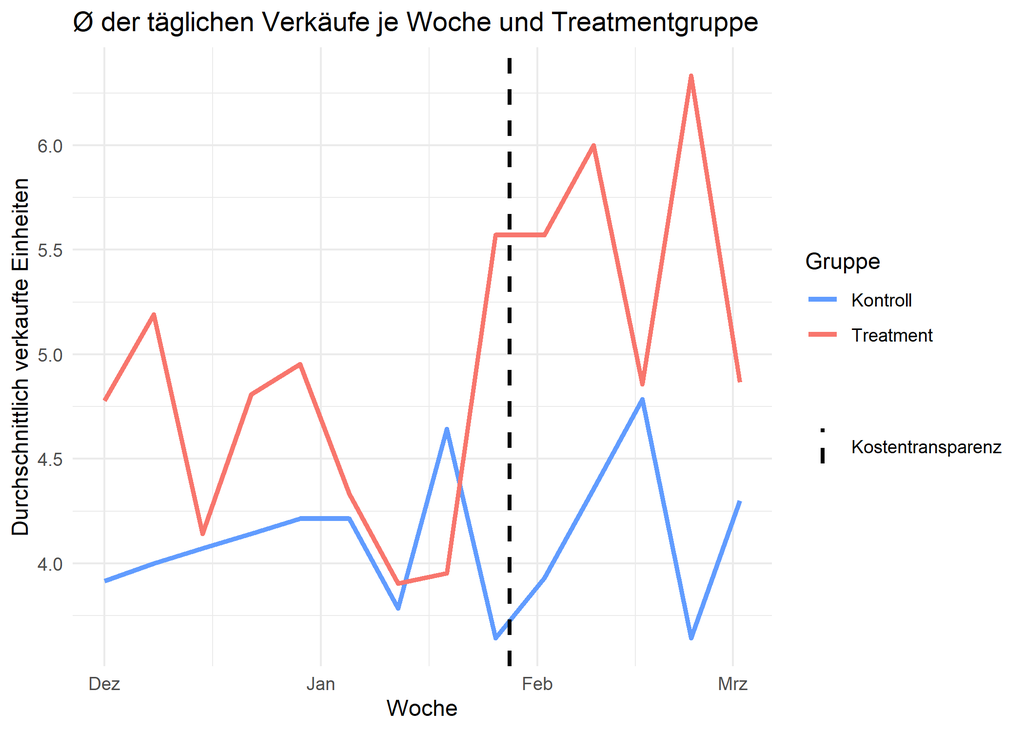

*Antwort:*

*Beschreibung*

Die dargestellte Grafik zeigt die durchschnittlich verkauften Einheiten pro Woche für zwei Gruppen: eine Kontrollgruppe (Treatment = 0, blau) und eine Treatment-Gruppe (Treatment = 1, rot). Auf der x-Achse sind die Kalenderwochen von Dezember 2013 bis März 2014 abgebildet, die y-Achse zeigt die durchschnittlich verkauften Einheiten. Eine vertikale gestrichelte Linie markiert den 28. Januar 2014, den Zeitpunkt der Einführung der Kostentransparenz in der Treatment-Gruppe.

*Entwicklung der Verkaufszahlen vor und nach der Maßnahme:*

Vor dem 28. Januar 2014 zeigt sich keine klare parallele Entwicklung in den beiden Gruppen. Während die Verkaufszahlen der Treatment-Gruppe schwanken und leichte Ausschläge nach oben und unten aufweisen, verläuft die Entwicklung in der Kontrollgruppe wesentlich stabiler und mit einem eher leichten Aufwärtstrend. Insbesondere in den Wochen unmittelbar vor dem Stichtag weichen die Verläufe deutlich voneinander ab. Dies legt nahe, dass sich die beiden Gruppen bereits vor der Einführung der Kostentransparenz unterschiedlich entwickelt haben. Nach dem 28. Januar 2014 steigen die Verkaufszahlen in der Treatment-Gruppe deutlich an. Dieser Trend ist visuell klar erkennbar. Auch die Kontrollgruppe zeigt einen Anstieg, allerdings deutlich weniger stark. Die Differenz zwischen den beiden Gruppen vergrößert sich somit nach der Intervention sichtbar.

*Visuelle Hinweise auf eine Wirkung der Kostentransparenz:*

Trotz des fehlenden parallelen Trends vor der Maßnahme liefert die Grafik Hinweise darauf, dass die Kostentransparenz mit einem deutlichen Anstieg der Verkaufszahlen in der Treatment-Gruppe verbunden ist. Allerdings kann dieser Effekt nicht eindeutig als kausaler Effekt interpretiert werden, da die Voraussetzung eines gleichen Ausgangstrends (Parallel-Trend-Annahme) nicht erfüllt zu sein scheint. Das bedeutet: Der beobachtete Anstieg könnte durch die Kostentransparenz verursacht worden sein, er könnte aber auch durch andere Faktoren erklärt werden, die bereits vor der Maßnahme unterschiedlich auf beide Gruppen gewirkt haben.

*Bedeutung für den Difference-in-Differences-Ansatz:*

Der Difference-in-Differences-Ansatz setzt voraus, dass beide Gruppen ohne die Intervention denselben zeitlichen Verlauf genommen hätten, das ist die sogenannte Parallel-Trend-Annahme. Wenn diese Annahme nicht erfüllt ist, wie es hier visuell den Anschein hat, dann ist die kausale Interpretation der Maßnahme als alleiniger Effekt nicht zuverlässig.

In einem solchen Fall muss man entweder:

-robustere Methoden anwenden (z. B. Matching, kontrollierte Regressionsmodelle, Trends kontrollieren),

-oder zusätzliche Daten einbeziehen, um den Grund für die unterschiedliche Entwicklung vor der Maßnahme zu verstehen und statistisch zu kontrollieren.

*Fazit:*

Die Grafik lässt vermuten, dass die Kostentransparenz eine Rolle beim Anstieg der Verkaufszahlen in der Treatment-Gruppe gespielt haben könnte. Allerdings ist aufgrund der fehlenden Parallelität der Trends vor der Intervention Vorsicht geboten. Eine einfache Difference-in-Differences-Analyse könnte hier zu verzerrten Ergebnissen führen, da die Gruppen sich schon vor der Maßnahme unterschiedlich entwickelt haben. Eine saubere kausale Interpretation ist unter diesen Bedingungen nicht ohne Weiteres möglich.

21. Erstellen Sie eine (mehrere) weitere passende Grafik(en), die die durchschnittlich verkauften Einheiten pro Tag in Treatment und Kontrolle vor und nach der Einführung der Kostentransparenz abbildet. Ergänzen Sie in ihrer Grafik die jeweiligen Standardfehler als Fehlerbalken. Beschreiben und interpretieren Sie ihre Grafik. Gehen Sie insbesondere auf die Unterschiede vor und nach der Einführung der Kostentransparenz ein.
- Inwiefern lassen sich daraus erste Hinweise auf einen möglichen Effekt des natürlichen Experiments erkennen?

*Hinweis:* Für die Erstellung der Grafik können Sie sich an Aufgabe 7 und 9 orientieren.

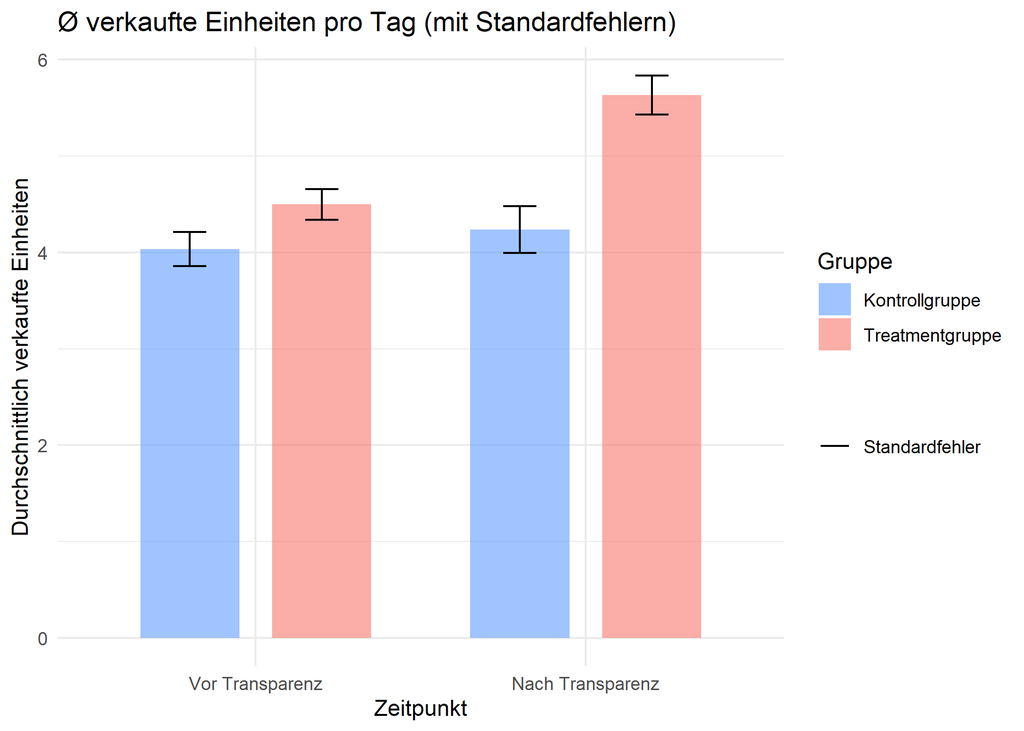

*Antwort:*

*Effekt des natürlichen Experiments*

Aus dieser Entwicklung lassen sich erste Hinweise auf einen möglichen Effekt des natürlichen Experiments ableiten. Die Tatsache, dass der starke Anstieg der Verkäufe nur in der Treatmentgruppe auftritt und sich nicht in der Kontrollgruppe widerspiegelt, legt nahe, dass die Einführung der Kostentransparenz einen positiven Einfluss auf das Kaufverhalten hatte. Besonders bemerkenswert ist, dass dieser Effekt nicht durch allgemeine Marktentwicklungen erklärt werden kann, da die Kontrollgruppe nur einen geringen Anstieg zeigt.

22. In der vorherigen Aufgabe haben Sie den Effekt von Kostentransparenz auf die Verkaufszahlen anhand eines deskriptiven Vergleichs untersucht. Dabei haben Sie die durchschnittlich täglich verkauften Einheiten je Treatment vor und nach der Einführung der Transparenzmaßnahme grafisch gegenübergestellt. In dieser Aufgabe sollen Sie diesen Effekt nun ökonometrisch genauer untersuchen, indem Sie den Difference-in-Differences Ansatz in einem Regressionsrahmen anwenden.

Untersuchen Sie den Effekt der Einführung von Kostentransparenz auf die Verkaufszahlen mithilfe einer Difference-in-Differences Regression. Verwenden Sie hierfür Beobachtungen an Werktagen, sowie am Wochenende (Montag bis Sonntag), mit positiven Verkaufszahlen.

Erstellen Sie insgesamt zwei Regressionsmodelle:

- Basismodell ohne Kontrollvariablen
- Modell mit Kontrolle für Wochentagseffekte

Stellen Sie die Ergebnisse anschaulich dar. Beschreiben und interpretieren Sie Ihre Ergebnisse. Gehen Sie insbesondere auf folgende Aspekte ein.

- Wie würden Sie die Größe des Effekts interpretieren, den Sie für `treated:post` erhalten haben?
- Welche Vorteile bringt es, log_units (logarithmierte Verkäufe) als abhängige Variable zu verwenden?
- Können Sie aus Ihrer Schätzung auf einen kausalen Effekt der Kostentransparenz schließen?
- Inwiefern hilft die Kontrolle für Wochentage dabei, Verzerrungen in der Schätzung zu vermeiden?
- Würden Sie auf Basis Ihrer Analyse eine Empfehlung zur Beibehaltung oder Ausweitung der Kostentransparenz geben?
- Worin könnten ihrer Ansicht nach Probleme liegen bei der Betrachtung eines natürlichen Experiments, die die Ergebnisse verzerren könnten?

*Hinweis 1:* Nutzen Sie für die Schätzung die `feols()`-Funktion aus dem fixest-Paket.

*Hinweis 2:* Nutzen Sie die logarithmierten täglichen Verkaufszahlen als abhängige Variable.

Ergebnisse der Difference-in-Differences(DiD) Regression (mit/ohne Wochentag-Kontrolle)

|  | Ohne Wochentag-Kontrolle | Mit Wochentag-Kontrolle |
| --- | --- | --- |
| Nach Post (post) | 0.066 | 0.065 |
|  | (0.077) | (0.077) |
| DiD-Effekt (treated:post) | 0.182+ | 0.182+ |
|  | (0.099) | (0.099) |
| Wochentag |  | 0.071 |
|  |  | (0.053) |
| Num.Obs. | 470 | 470 |
| R2 | 0.060 | 0.064 |
| R2 Adj. | 0.054 | 0.056 |
| AIC | 716.7 | 716.9 |
| BIC | 733.3 | 737.7 |
| RMSE | 0.51 | 0.51 |

+ p < 0.1, * p < 0.05, ** p < 0.01, *** p < 0.001

**Antwort**

**Beschreibung der Ergebnisse**

Die Tabelle zeigt die Ergebnisse zweier Difference-in-Differences (DiD) Regressionen, die den Einfluss der Einführung von Kostentransparenz auf die logarithmierten Verkaufszahlen analysieren. Im Basismodell ohne Kontrollvariablen beträgt der geschätzte Effekt der Maßnahme (treated:post) 0.182 mit einem Standardfehler von 0.099. Auch im erweiterten Modell mit Kontrolle für Wochentage bleibt der Effekt unverändert. Dieser Effekt ist schwach signifikant auf dem 10%-Niveau (p < 0.1), was auf einen potenziellen Zusammenhang hindeutet. Die Kontrollvariable für Wochentage zeigt einen positiven, aber nicht signifikanten Effekt auf die Verkaufszahlen. Die Modellgüte (AIC, BIC, RMSE) bleibt durch die Hinzunahme der Wochentagskontrolle nahezu unverändert.

**Größe des DiD-Effekts (treated:post)**

Der Koeffizient von 0.182 für den Interaktionsterm treated:post lässt sich als relativer Effekt interpretieren, da die abhängige Variable logarithmiert ist. Dies bedeutet, dass die Einführung der Kostentransparenz mit einem durchschnittlichen Anstieg der täglichen Verkaufszahlen in der Treatmentgruppe von etwa 20 % verbunden ist genauer: $e^{0.182} - 1 \approx 0.20$. Diese Größenordnung ist wirtschaftlich durchaus relevant und deutet auf eine spürbare Veränderung im Kaufverhalten hin. Die Tatsache, dass der Effekt über beide Modellvarianten hinweg stabil bleibt, stärkt die Robustheit der Ergebnisse. Allerdings ist der Effekt statistisch nur schwach signifikant (p < 0.1), weshalb er mit Vorsicht zu interpretieren ist.

**Vorteile von log_units als abhängige Variable**

Die Verwendung der logarithmierten Verkaufszahlen (log_units) als abhängige Variable bringt mehrere Vorteile mit sich. Zum einen werden große Ausreißer, etwa sehr hohe Verkaufszahlen an einzelnen Tagen, abgeschwächt und verzerren das Modell weniger stark. Zum anderen ermöglicht die logarithmische Transformation eine Interpretation der Koeffizienten in Prozentänderungen, was intuitiv verständlicher ist als absolute Einheiten. Zudem verbessert sie häufig die Modellanpassung bei rechtsschief verteilten Daten.

**Kausalität der Schätzung – Ist ein kausaler Effekt ableitbar?**

Die Kontrolle für Wochentage dient dazu, systematische Schwankungen in den Verkaufszahlen zwischen Werktagen und Wochenenden zu berücksichtigen. Solche Schwankungen könnten sonst fälschlich dem Treatmenteffekt zugeschrieben werden. In diesem Fall ist der Effekt der Wochentage selbst zwar nicht signifikant, doch die Berücksichtigung verbessert die Robustheit der Schätzung. Die Konstanz des DiD-Koeffizienten zwischen beiden Modellen spricht dafür, dass der geschätzte Effekt nicht durch unterschiedliche Tagesmuster verzerrt ist. Damit trägt die Kontrolle zur Validität und Reliabilität der Analyse bei.

**Empfehlung zur Beibehaltung oder Ausweitung der Transparenzmaßnahme**

Auf Basis der vorliegenden Analyse spricht vieles für eine Beibehaltung oder sogar Ausweitung der Kostentransparenz. Der Effekt ist wirtschaftlich relevant und robust gegenüber der Einbeziehung von Wochentagseffekten. Auch wenn die Signifikanz nicht über alle Zweifel erhaben ist, deuten die Daten klar in eine positive Richtung. Da die Maßnahme vermutlich sehr geringe zusätzliche Kosten verursacht, kann sie als günstiges Marketinginstrument genutzt werden.

**Mögliche Verzerrungsquellen im natürlichen Experiment**

Auch wenn natürliche Experimente viele Vorteile bieten, sind sie nicht frei von potenziellen Verzerrungen. So könnten unbeobachtete Unterschiede zwischen den Farbvarianten (z. B. Beliebtheit, Saisonabhängigkeit) mit der Treatmentzuweisung korrelieren und so die Ergebnisse verfälschen. Ebenso wäre denkbar, dass die zufällige Transparenzanzeige zufällig mit Werbeaktionen oder externen Faktoren zusammenfiel. Auch unterschiedliche Verfügbarkeiten oder Lagerbestände könnten eine Rolle spielen. Schließlich bleibt die Parallel-Trend-Annahme unbeweisbar und sollte kritisch reflektiert werden. Insgesamt ist es wichtig, solche Limitationen bei der Interpretation der Ergebnisse im Hinterkopf zu behalten.

# Literatur

Mohan, B., Buell, R. W., & John, L. K. (2020). Lifting the veil: The benefits of cost transparency. Marketing Science, 39(6), 1105-1121. https://doi.org/10.1287/mksc.2019.1200

# Anhang

## Mediator

Im Rahmen von Mediationen ist der Mediator eine Variable, die den erklärenden Zusammenhang zwischen einer unabhängigen und einer abhängigen Variable vermittelt. Dabei wird untersucht, inwieweit der Einfluss der unabhängigen Variablen (z.B. Kostentransparenz) auf die abhängige Variable (z.B. Kaufabsicht) über einen vermittelnden Mechanismus - wie das Vertrauen der Kunden - erfolgt.

1. **Mediatoreffekt**: Der Mediatoren-Effekt, oft als ACME (Average Causal Mediation Effect) bezeichnet, beschreibt den indirekten Effekt, den die unabhängige Variable auf die abhängige Variable über den Mediator ausübt. Ist dieser Effekt signifikant, signalisiert dies, dass ein wesentlicher Teil des gesamten Einflusses über den vermittelnden Mechanismus läuft. Gleichzeitig kann ein nicht-signifikanter direkter Effekt (ADE - Average Direct Effect) darauf hindeuten, dass der Mediator den hauptsächlichen Erklärungsmechanismus darstellt.
2. **Funktion und Wirkung des Mediators**: Analog zum Konzept der signalgebenden Funktion bei Statussymbolen - deren Wert unter anderem von der Exklusivität und dem sozialen Kontext abhängt - fungiert der Mediator als vermittelnder Kanal, der erklärt, wie und warum der ursprüngliche Zusammenhang zwischen zwei Variablen zustande kommt. Der Mediator „überträgt“ quasi den Effekt der unabhängigen Variable auf die abhängige Variable. Dadurch kann in Modellen, in denen der direkte Zusammenhang zwischen der unabhängigen und der abhängigen Variable durch die Einbeziehung des Mediators verschwindet oder abgeschwächt wird, abgeleitet werden, dass der Mechanismus über den Mediator läuft. Dies ermöglicht ein tieferes Verständnis der zugrundeliegenden psychologischen Prozesse - etwa wie das Vertrauen der Kunden die Wirkung von Kostentransparenz auf deren Kaufabsicht vermittelt.

Zusammengefasst spielt der Mediator eine zentrale Rolle bei der Aufklärung der kausalen Mechanismen, indem er als vermittelnder Faktor zwischen Ursache und Wirkung identifiziert wird. Die signifikante Vermittlung über den Mediator zeigt, dass nicht allein das Vorhandensein von Kostentransparenz entscheidend ist, sondern auch, inwiefern diese Transparenz das Vertrauen stärkt - was wiederum maßgeblich die Kaufabsicht beeinflusst. So liefert die Mediationsanalyse wertvolle Einsichten, die über einfache bivariate Zusammenhänge hinausgehen und die Komplexität kausaler Mechanismen innerhalb von sozialen oder marktorientierten Prozessen sichtbar machen.

## Informationen zum Studiendesign des Experiments 1 und 2

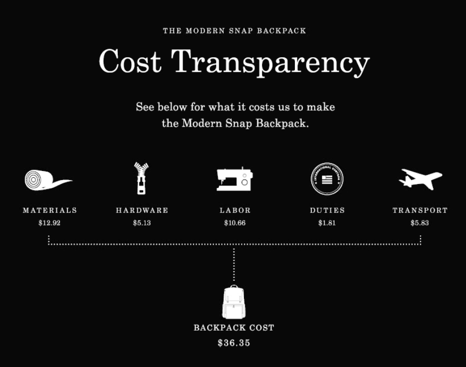

Abbildung 1: Kostentransparenz Infografik

[figure not shown]

Abbildung 2: Design der Schokoladenverpackung ohne und mit Kostentransparenz